# Spline Simulations Full Results

2026-10-05

## Summary of the Results

```r
library(dplyr)
library(purrr)
library(tidyr)
library(knitr)
library(kableExtra)
library(ggplot2)
library(ggrepel)

data_dir <- "sim_results"
file_list <- list.files(path = data_dir, pattern = "res_scen_.*_chunk_.*\\.rds",
                        full.names = TRUE)

raw_sim_data <- file_list %>% map_dfr(readRDS)

summary_stats <- raw_sim_data %>%
 select(-starts_with("pt_cov_")) %>%
 group_by(n, sigma_true, K, Alpha_Setting, Method) %>%
 summarise(
  Reps = n(),
  Failures = sum(Failed, na.rm = TRUE),
  Mean_RMSE = mean(RMSE, na.rm = TRUE),
  Empirical_Coverage = mean(Coverage, na.rm = TRUE),

  Bias_Sigma = mean(Bias_Sigma, na.rm = TRUE),
  Cov_Sigma = mean(Cov_Sigma, na.rm = TRUE),

  # ratio of the estimated $\tau^2$ to the Oracle $\tau^2$
  Mean_Tau2_Ratio = mean(Tau2_Est / (Tau2_Est - Bias_Tau2), na.rm = TRUE),

  Bias_Tau2 = mean(Bias_Tau2, na.rm = TRUE),
    Cov_Tau2 = mean(Cov_Tau2, na.rm = TRUE),

  Bias_Alpha_1 = mean(Bias_Alpha_1, na.rm = TRUE),
  Cov_Alpha_1 = mean(Cov_Alpha_1, na.rm = TRUE),
  Bias_Alpha_2 = mean(Bias_Alpha_2, na.rm = TRUE),
  Cov_Alpha_2 = mean(Cov_Alpha_2, na.rm = TRUE),
  Bias_Alpha_3 = mean(Bias_Alpha_3, na.rm = TRUE),
  Cov_Alpha_3 = mean(Cov_Alpha_3, na.rm = TRUE),
  Bias_Alpha_4 = mean(Bias_Alpha_4, na.rm = TRUE),
  Cov_Alpha_4 = mean(Cov_Alpha_4, na.rm = TRUE),

  Avg_Time_Sec = mean(Time, na.rm = TRUE),
  .groups = "drop"
 ) %>%
 arrange(K, n, sigma_true, factor(Method,
                                  levels = c("Oracle", "Naive", "ELE_n1_5",
                                             "ELE_n1_2", "ELE_GCV", "ELE_REML",
                                             "Gibbs", "VB")))

table_function_est <- summary_stats %>%
 select(K, n, sigma_true, Alpha_Setting, Method, Mean_RMSE, Empirical_Coverage, Avg_Time_Sec) %>%
 mutate(
  Mean_RMSE = sprintf("%.4f", Mean_RMSE),
  Empirical_Coverage = sprintf("%.3f", Empirical_Coverage),
  Avg_Time_Sec = sprintf("%.2f", Avg_Time_Sec)
 )

table_variance_comp <- summary_stats %>%
 select(K, n, sigma_true, Alpha_Setting, Method, Bias_Sigma, Cov_Sigma, Mean_Tau2_Ratio, Bias_Tau2, Cov_Tau2) %>%
 filter(!Method %in% c("Oracle", "Naive") | !is.na(Bias_Sigma)) %>%
 mutate(
  Bias_Sigma = ifelse(is.na(Bias_Sigma), "-", sprintf("%.4f", Bias_Sigma)),
  Cov_Sigma = ifelse(is.na(Cov_Sigma), "-", sprintf("%.3f", Cov_Sigma)),
  Mean_Tau2_Ratio = ifelse(is.na(Mean_Tau2_Ratio), "-", sprintf("%.3f", Mean_Tau2_Ratio)),
  Bias_Tau2 = ifelse(is.na(Bias_Tau2), "-", sprintf("%.4f", Bias_Tau2)),
  Cov_Tau2 = ifelse(is.na(Cov_Tau2), "-", sprintf("%.3f", Cov_Tau2))
 )

table_alpha_K1 <- summary_stats %>%
 filter(K == 1, Method %in% c("Gibbs", "VB", "ELE_n1_5", "ELE_n1_2", "ELE_GCV", "ELE_REML")) %>%
 select(n, sigma_true, Alpha_Setting, Method, Bias_Alpha_1, Cov_Alpha_1) %>%
 mutate(across(starts_with("Bias"), ~ ifelse(is.na(.), "-", sprintf("%.4f", .))),
        across(starts_with("Cov"), ~ ifelse(is.na(.), "-", sprintf("%.3f", .))))

table_alpha_K4 <- summary_stats %>%
 filter(K == 4, Method %in% c("Gibbs", "VB", "ELE_n1_5", "ELE_n1_2", "ELE_GCV", "ELE_REML")) %>%
 select(n, sigma_true, Alpha_Setting, Method, starts_with("Bias_Alpha"), starts_with("Cov_Alpha")) %>%
 mutate(across(starts_with("Bias"), ~ ifelse(is.na(.), "-", sprintf("%.4f", .))),
        across(starts_with("Cov"), ~ ifelse(is.na(.), "-", sprintf("%.3f", .))))

table_failures <- summary_stats %>%
 mutate(Failures_Report = paste0(Failures, " / ", Reps)) %>%
 select(K, Alpha_Setting, n, sigma_true, Method, Failures_Report) %>%
 arrange(K, Alpha_Setting, n, sigma_true)
```

### Tables

#### Spline Function Estimation & Run Time

##### (Single Block, K=1)

```r
for(a in unique(table_function_est$Alpha_Setting[table_function_est$K == 1])) {
  cat("###### Alpha Setting: ", a, "\n\n")

  out <- table_function_est %>%
    filter(K == 1, Alpha_Setting == a) %>%
    select(-K, -Alpha_Setting) %>%
    kbl(align = "c", col.names = c("n", "Sigma", "Method", "Mean RMSE", "Coverage", "Time (sec)")) %>%
    kable_styling(bootstrap_options = c("striped", "hover", "condensed", "bordered"), full_width = FALSE, font_size = 12) %>%
    collapse_rows(columns = 1:2, valign = "middle")

  cat(out, "\n\n")
}
```

###### Alpha Setting: 0.05

| n | Sigma | Method | Mean RMSE | Coverage | Time (sec) |
| --- | --- | --- | --- | --- | --- |
| 500 | 0.10 | Oracle | 0.0142 | 0.969 | 0.03 |
|  |  | Naive | 0.0432 | 0.841 | 0.03 |
|  |  | ELE_n1_5 | 0.0509 | 0.949 | 0.06 |
|  |  | ELE_n1_2 | 0.0435 | 0.953 | 0.06 |
|  |  | ELE_GCV | 0.0293 | 0.958 | 0.08 |
|  |  | ELE_REML | 0.0311 | 0.960 | 0.10 |
|  |  | Gibbs | 0.0149 | 0.970 | 0.71 |
|  |  | VB | 0.0148 | 0.966 | 0.17 |
|  | 0.25 | Oracle | 0.0303 | 0.969 | 0.03 |
|  |  | Naive | 0.0499 | 0.888 | 0.03 |
|  |  | ELE_n1_5 | 0.0723 | 0.946 | 0.06 |
|  |  | ELE_n1_2 | 0.0621 | 0.946 | 0.06 |
|  |  | ELE_GCV | 0.0406 | 0.945 | 0.08 |
|  |  | ELE_REML | 0.0421 | 0.951 | 0.10 |
|  |  | Gibbs | 0.0319 | 0.971 | 0.71 |
|  |  | VB | 0.0316 | 0.964 | 0.17 |
|  | 0.75 | Oracle | 0.0751 | 0.968 | 0.03 |
|  |  | Naive | 0.0857 | 0.943 | 0.03 |
|  |  | ELE_n1_5 | 0.1747 | 0.945 | 0.06 |
|  |  | ELE_n1_2 | 0.1496 | 0.946 | 0.06 |
|  |  | ELE_GCV | 0.0896 | 0.938 | 0.07 |
|  |  | ELE_REML | 0.0871 | 0.950 | 0.09 |
|  |  | Gibbs | 0.0821 | 0.976 | 0.60 |
|  |  | VB | 0.0806 | 0.959 | 0.15 |
|  | 1.00 | Oracle | 0.0982 | 0.962 | 0.03 |
|  |  | Naive | 0.1073 | 0.941 | 0.03 |
|  |  | ELE_n1_5 | 0.2301 | 0.944 | 0.06 |
|  |  | ELE_n1_2 | 0.1973 | 0.945 | 0.07 |
|  |  | ELE_GCV | 0.1143 | 0.934 | 0.08 |
|  |  | ELE_REML | 0.1104 | 0.945 | 0.10 |
|  |  | Gibbs | 0.1155 | 0.971 | 0.72 |
|  |  | VB | 0.1099 | 0.947 | 0.18 |
|  | 1.25 | Oracle | 0.1200 | 0.957 | 0.03 |
|  |  | Naive | 0.1282 | 0.935 | 0.03 |
|  |  | ELE_n1_5 | 0.2851 | 0.944 | 0.06 |
|  |  | ELE_n1_2 | 0.2458 | 0.944 | 0.06 |
|  |  | ELE_GCV | 0.1392 | 0.927 | 0.07 |
|  |  | ELE_REML | 0.1335 | 0.939 | 0.09 |
|  |  | Gibbs | 0.1678 | 0.959 | 0.70 |
|  |  | VB | 0.1535 | 0.915 | 0.17 |
| 2000 | 0.10 | Oracle | 0.0081 | 0.968 | 0.05 |
|  |  | Naive | 0.0369 | 0.609 | 0.04 |
|  |  | ELE_n1_5 | 0.0265 | 0.954 | 0.46 |
|  |  | ELE_n1_2 | 0.0236 | 0.955 | 0.46 |
|  |  | ELE_GCV | 0.0163 | 0.956 | 0.48 |
|  |  | ELE_REML | 0.0180 | 0.958 | 0.53 |
|  |  | Gibbs | 0.0085 | 0.969 | 1.26 |
|  |  | VB | 0.0084 | 0.966 | 0.46 |
|  | 0.25 | Oracle | 0.0173 | 0.969 | 0.04 |
|  |  | Naive | 0.0399 | 0.725 | 0.04 |
|  |  | ELE_n1_5 | 0.0373 | 0.953 | 0.45 |
|  |  | ELE_n1_2 | 0.0333 | 0.953 | 0.45 |
|  |  | ELE_GCV | 0.0222 | 0.950 | 0.48 |
|  |  | ELE_REML | 0.0241 | 0.954 | 0.53 |
|  |  | Gibbs | 0.0181 | 0.971 | 1.25 |
|  |  | VB | 0.0180 | 0.966 | 0.46 |
|  | 0.75 | Oracle | 0.0424 | 0.971 | 0.05 |
|  |  | Naive | 0.0555 | 0.902 | 0.05 |
|  |  | ELE_n1_5 | 0.0904 | 0.950 | 0.46 |
|  |  | ELE_n1_2 | 0.0808 | 0.950 | 0.46 |
|  |  | ELE_GCV | 0.0490 | 0.941 | 0.49 |
|  |  | ELE_REML | 0.0499 | 0.949 | 0.53 |
|  |  | Gibbs | 0.0461 | 0.973 | 1.28 |
|  |  | VB | 0.0454 | 0.961 | 0.47 |
|  | 1.00 | Oracle | 0.0541 | 0.968 | 0.05 |
|  |  | Naive | 0.0651 | 0.923 | 0.05 |
|  |  | ELE_n1_5 | 0.1185 | 0.948 | 0.44 |
|  |  | ELE_n1_2 | 0.1061 | 0.948 | 0.44 |
|  |  | ELE_GCV | 0.0623 | 0.936 | 0.46 |
|  |  | ELE_REML | 0.0625 | 0.946 | 0.50 |
|  |  | Gibbs | 0.0617 | 0.971 | 1.23 |
|  |  | VB | 0.0611 | 0.950 | 0.45 |
|  | 1.25 | Oracle | 0.0660 | 0.966 | 0.06 |
|  |  | Naive | 0.0759 | 0.929 | 0.06 |
|  |  | ELE_n1_5 | 0.1489 | 0.947 | 0.46 |
|  |  | ELE_n1_2 | 0.1329 | 0.946 | 0.45 |
|  |  | ELE_GCV | 0.0772 | 0.933 | 0.48 |
|  |  | ELE_REML | 0.0756 | 0.944 | 0.52 |
|  |  | Gibbs | 0.0845 | 0.959 | 1.25 |
|  |  | VB | 0.0909 | 0.897 | 0.46 |

###### Alpha Setting: 0.15

| n | Sigma | Method | Mean RMSE | Coverage | Time (sec) |
| --- | --- | --- | --- | --- | --- |
| 500 | 0.10 | Oracle | 0.0142 | 0.969 | 0.03 |
|  |  | Naive | 0.1094 | 0.478 | 0.03 |
|  |  | ELE_n1_5 | 0.0903 | 0.953 | 0.06 |
|  |  | ELE_n1_2 | 0.0760 | 0.955 | 0.06 |
|  |  | ELE_GCV | 0.0487 | 0.959 | 0.08 |
|  |  | ELE_REML | 0.0491 | 0.964 | 0.10 |
|  |  | Gibbs | 0.0162 | 0.968 | 0.72 |
|  |  | VB | 0.0161 | 0.958 | 0.17 |
|  | 0.25 | Oracle | 0.0303 | 0.969 | 0.03 |
|  |  | Naive | 0.1137 | 0.541 | 0.03 |
|  |  | ELE_n1_5 | 0.1073 | 0.944 | 0.06 |
|  |  | ELE_n1_2 | 0.0908 | 0.946 | 0.06 |
|  |  | ELE_GCV | 0.0579 | 0.947 | 0.08 |
|  |  | ELE_REML | 0.0580 | 0.952 | 0.10 |
|  |  | Gibbs | 0.0347 | 0.973 | 0.71 |
|  |  | VB | 0.0342 | 0.959 | 0.17 |
|  | 0.75 | Oracle | 0.0751 | 0.968 | 0.02 |
|  |  | Naive | 0.1317 | 0.776 | 0.02 |
|  |  | ELE_n1_5 | 0.2041 | 0.947 | 0.04 |
|  |  | ELE_n1_2 | 0.1723 | 0.949 | 0.04 |
|  |  | ELE_GCV | 0.1008 | 0.943 | 0.05 |
|  |  | ELE_REML | 0.0980 | 0.952 | 0.06 |
|  |  | Gibbs | 0.0906 | 0.977 | 0.38 |
|  |  | VB | 0.0890 | 0.945 | 0.10 |
|  | 1.00 | Oracle | 0.0982 | 0.962 | 0.03 |
|  |  | Naive | 0.1473 | 0.818 | 0.03 |
|  |  | ELE_n1_5 | 0.2624 | 0.945 | 0.06 |
|  |  | ELE_n1_2 | 0.2221 | 0.947 | 0.06 |
|  |  | ELE_GCV | 0.1276 | 0.934 | 0.08 |
|  |  | ELE_REML | 0.1222 | 0.944 | 0.10 |
|  |  | Gibbs | 0.1257 | 0.977 | 0.71 |
|  |  | VB | 0.1192 | 0.935 | 0.17 |
|  | 1.25 | Oracle | 0.1200 | 0.957 | 0.03 |
|  |  | Naive | 0.1644 | 0.840 | 0.03 |
|  |  | ELE_n1_5 | 0.3201 | 0.947 | 0.06 |
|  |  | ELE_n1_2 | 0.2708 | 0.948 | 0.06 |
|  |  | ELE_GCV | 0.1505 | 0.931 | 0.08 |
|  |  | ELE_REML | 0.1442 | 0.944 | 0.10 |
|  |  | Gibbs | 0.1822 | 0.971 | 0.71 |
|  |  | VB | 0.1601 | 0.916 | 0.17 |
| 2000 | 0.10 | Oracle | 0.0081 | 0.968 | 0.05 |
|  |  | Naive | 0.1038 | 0.265 | 0.05 |
|  |  | ELE_n1_5 | 0.0470 | 0.953 | 0.47 |
|  |  | ELE_n1_2 | 0.0410 | 0.954 | 0.46 |
|  |  | ELE_GCV | 0.0267 | 0.956 | 0.48 |
|  |  | ELE_REML | 0.0285 | 0.959 | 0.53 |
|  |  | Gibbs | 0.0091 | 0.968 | 1.25 |
|  |  | VB | 0.0090 | 0.960 | 0.45 |
|  | 0.25 | Oracle | 0.0173 | 0.969 | 0.04 |
|  |  | Naive | 0.1051 | 0.299 | 0.05 |
|  |  | ELE_n1_5 | 0.0553 | 0.952 | 0.46 |
|  |  | ELE_n1_2 | 0.0484 | 0.953 | 0.45 |
|  |  | ELE_GCV | 0.0310 | 0.953 | 0.48 |
|  |  | ELE_REML | 0.0326 | 0.957 | 0.52 |
|  |  | Gibbs | 0.0198 | 0.973 | 1.28 |
|  |  | VB | 0.0196 | 0.959 | 0.45 |
|  | 0.75 | Oracle | 0.0424 | 0.971 | 0.05 |
|  |  | Naive | 0.1118 | 0.526 | 0.06 |
|  |  | ELE_n1_5 | 0.1071 | 0.950 | 0.46 |
|  |  | ELE_n1_2 | 0.0937 | 0.950 | 0.45 |
|  |  | ELE_GCV | 0.0556 | 0.946 | 0.48 |
|  |  | ELE_REML | 0.0561 | 0.953 | 0.52 |
|  |  | Gibbs | 0.0507 | 0.976 | 1.27 |
|  |  | VB | 0.0496 | 0.951 | 0.46 |
|  | 1.00 | Oracle | 0.0541 | 0.968 | 0.06 |
|  |  | Naive | 0.1168 | 0.628 | 0.06 |
|  |  | ELE_n1_5 | 0.1362 | 0.949 | 0.45 |
|  |  | ELE_n1_2 | 0.1195 | 0.949 | 0.45 |
|  |  | ELE_GCV | 0.0692 | 0.940 | 0.47 |
|  |  | ELE_REML | 0.0692 | 0.949 | 0.51 |
|  |  | Gibbs | 0.0679 | 0.975 | 1.28 |
|  |  | VB | 0.0651 | 0.946 | 0.46 |
|  | 1.25 | Oracle | 0.0660 | 0.966 | 0.06 |
|  |  | Naive | 0.1246 | 0.691 | 0.06 |
|  |  | ELE_n1_5 | 0.1698 | 0.946 | 0.46 |
|  |  | ELE_n1_2 | 0.1489 | 0.946 | 0.46 |
|  |  | ELE_GCV | 0.0849 | 0.934 | 0.48 |
|  |  | ELE_REML | 0.0831 | 0.945 | 0.52 |
|  |  | Gibbs | 0.0937 | 0.963 | 1.29 |
|  |  | VB | 0.0924 | 0.904 | 0.46 |

###### Alpha Setting: 0.3

| n | Sigma | Method | Mean RMSE | Coverage | Time (sec) |
| --- | --- | --- | --- | --- | --- |
| 500 | 0.10 | Oracle | 0.0142 | 0.969 | 0.03 |
|  |  | Naive | 0.2110 | 0.274 | 0.03 |
|  |  | ELE_n1_5 | 0.1418 | 0.956 | 0.06 |
|  |  | ELE_n1_2 | 0.1172 | 0.957 | 0.06 |
|  |  | ELE_GCV | 0.0733 | 0.958 | 0.08 |
|  |  | ELE_REML | 0.0720 | 0.963 | 0.09 |
|  |  | Gibbs | 0.0180 | 0.971 | 0.71 |
|  |  | VB | 0.0178 | 0.953 | 0.17 |
|  | 0.25 | Oracle | 0.0303 | 0.969 | 0.03 |
|  |  | Naive | 0.2106 | 0.297 | 0.03 |
|  |  | ELE_n1_5 | 0.1561 | 0.949 | 0.06 |
|  |  | ELE_n1_2 | 0.1287 | 0.950 | 0.06 |
|  |  | ELE_GCV | 0.0793 | 0.950 | 0.07 |
|  |  | ELE_REML | 0.0778 | 0.957 | 0.09 |
|  |  | Gibbs | 0.0398 | 0.975 | 0.71 |
|  |  | VB | 0.0391 | 0.946 | 0.17 |
|  | 0.75 | Oracle | 0.0751 | 0.968 | 0.02 |
|  |  | Naive | 0.2250 | 0.449 | 0.02 |
|  |  | ELE_n1_5 | 0.2576 | 0.949 | 0.04 |
|  |  | ELE_n1_2 | 0.2127 | 0.949 | 0.04 |
|  |  | ELE_GCV | 0.1248 | 0.938 | 0.05 |
|  |  | ELE_REML | 0.1190 | 0.950 | 0.06 |
|  |  | Gibbs | 0.1066 | 0.979 | 0.34 |
|  |  | VB | 0.1043 | 0.921 | 0.09 |
|  | 1.00 | Oracle | 0.0982 | 0.962 | 0.03 |
|  |  | Naive | 0.2346 | 0.529 | 0.03 |
|  |  | ELE_n1_5 | 0.3246 | 0.947 | 0.06 |
|  |  | ELE_n1_2 | 0.2692 | 0.948 | 0.06 |
|  |  | ELE_GCV | 0.1566 | 0.930 | 0.08 |
|  |  | ELE_REML | 0.1457 | 0.943 | 0.10 |
|  |  | Gibbs | 0.1500 | 0.979 | 0.74 |
|  |  | VB | 0.1399 | 0.911 | 0.18 |
|  | 1.25 | Oracle | 0.1199 | 0.958 | 0.03 |
|  |  | Naive | 0.2482 | 0.583 | 0.04 |
|  |  | ELE_n1_5 | 0.3909 | 0.946 | 0.06 |
|  |  | ELE_n1_2 | 0.3231 | 0.947 | 0.06 |
|  |  | ELE_GCV | 0.1827 | 0.923 | 0.08 |
|  |  | ELE_REML | 0.1700 | 0.937 | 0.10 |
|  |  | Gibbs | 0.2505 | 0.968 | 0.74 |
|  |  | VB | 0.1867 | 0.892 | 0.17 |
| 2000 | 0.10 | Oracle | 0.0081 | 0.968 | 0.05 |
|  |  | Naive | 0.2053 | 0.171 | 0.05 |
|  |  | ELE_n1_5 | 0.0753 | 0.953 | 0.45 |
|  |  | ELE_n1_2 | 0.0636 | 0.954 | 0.45 |
|  |  | ELE_GCV | 0.0402 | 0.957 | 0.47 |
|  |  | ELE_REML | 0.0414 | 0.961 | 0.51 |
|  |  | Gibbs | 0.0103 | 0.968 | 1.31 |
|  |  | VB | 0.0102 | 0.951 | 0.45 |
|  | 0.25 | Oracle | 0.0173 | 0.969 | 0.04 |
|  |  | Naive | 0.2063 | 0.183 | 0.05 |
|  |  | ELE_n1_5 | 0.0839 | 0.950 | 0.46 |
|  |  | ELE_n1_2 | 0.0709 | 0.951 | 0.46 |
|  |  | ELE_GCV | 0.0442 | 0.952 | 0.48 |
|  |  | ELE_REML | 0.0453 | 0.957 | 0.52 |
|  |  | Gibbs | 0.0225 | 0.973 | 1.34 |
|  |  | VB | 0.0221 | 0.947 | 0.46 |
|  | 0.75 | Oracle | 0.0424 | 0.971 | 0.05 |
|  |  | Naive | 0.2103 | 0.254 | 0.06 |
|  |  | ELE_n1_5 | 0.1364 | 0.952 | 0.45 |
|  |  | ELE_n1_2 | 0.1155 | 0.952 | 0.45 |
|  |  | ELE_GCV | 0.0680 | 0.946 | 0.47 |
|  |  | ELE_REML | 0.0679 | 0.955 | 0.51 |
|  |  | Gibbs | 0.0590 | 0.980 | 1.29 |
|  |  | VB | 0.0579 | 0.927 | 0.45 |
|  | 1.00 | Oracle | 0.0541 | 0.968 | 0.06 |
|  |  | Naive | 0.2134 | 0.300 | 0.06 |
|  |  | ELE_n1_5 | 0.1713 | 0.950 | 0.47 |
|  |  | ELE_n1_2 | 0.1454 | 0.949 | 0.46 |
|  |  | ELE_GCV | 0.0850 | 0.938 | 0.49 |
|  |  | ELE_REML | 0.0826 | 0.948 | 0.53 |
|  |  | Gibbs | 0.0806 | 0.975 | 1.34 |
|  |  | VB | 0.0758 | 0.916 | 0.47 |
|  | 1.25 | Oracle | 0.0660 | 0.966 | 0.06 |
|  |  | Naive | 0.2174 | 0.352 | 0.06 |
|  |  | ELE_n1_5 | 0.2068 | 0.950 | 0.44 |
|  |  | ELE_n1_2 | 0.1753 | 0.950 | 0.44 |
|  |  | ELE_GCV | 0.0995 | 0.938 | 0.46 |
|  |  | ELE_REML | 0.0959 | 0.950 | 0.50 |
|  |  | Gibbs | 0.1084 | 0.973 | 1.30 |
|  |  | VB | 0.0979 | 0.911 | 0.46 |

##### (Four Blocks, K=4)

```r
for(a in unique(table_function_est$Alpha_Setting[table_function_est$K == 4])) {
  cat("###### Alpha Setting: ", a, "\n\n")

  out <- table_function_est %>%
    filter(K == 4, Alpha_Setting == a) %>%
    select(-K, -Alpha_Setting) %>%
    kbl(align = "c", col.names = c("n", "Sigma", "Method", "Mean RMSE", "Coverage", "Time (sec)")) %>%
    kable_styling(bootstrap_options = c("striped", "hover", "condensed", "bordered"), full_width = FALSE, font_size = 12) %>%
    collapse_rows(columns = 1:2, valign = "middle")

  cat(out, "\n\n")
}
```

###### Alpha Setting: 0.05_0.1_0.2_0.3

| n | Sigma | Method | Mean RMSE | Coverage | Time (sec) |
| --- | --- | --- | --- | --- | --- |
| 500 | 0.10 | Oracle | 0.0142 | 0.970 | 0.03 |
|  |  | Naive | 0.1174 | 0.449 | 0.03 |
|  |  | ELE_n1_5 | 0.0873 | 0.956 | 0.05 |
|  |  | ELE_n1_2 | 0.0733 | 0.958 | 0.05 |
|  |  | ELE_GCV | 0.0454 | 0.963 | 0.07 |
|  |  | ELE_REML | 0.0468 | 0.966 | 0.09 |
|  |  | Gibbs | 0.0161 | 0.972 | 0.77 |
|  |  | VB | 0.0160 | 0.963 | 0.17 |
|  | 0.25 | Oracle | 0.0305 | 0.970 | 0.03 |
|  |  | Naive | 0.1195 | 0.515 | 0.03 |
|  |  | ELE_n1_5 | 0.1048 | 0.943 | 0.06 |
|  |  | ELE_n1_2 | 0.0883 | 0.945 | 0.06 |
|  |  | ELE_GCV | 0.0541 | 0.951 | 0.07 |
|  |  | ELE_REML | 0.0554 | 0.956 | 0.09 |
|  |  | Gibbs | 0.0349 | 0.973 | 0.80 |
|  |  | VB | 0.0345 | 0.958 | 0.18 |
|  | 0.75 | Oracle | 0.0770 | 0.964 | 0.02 |
|  |  | Naive | 0.1410 | 0.737 | 0.03 |
|  |  | ELE_n1_5 | 0.2058 | 0.944 | 0.04 |
|  |  | ELE_n1_2 | 0.1739 | 0.945 | 0.05 |
|  |  | ELE_GCV | 0.1028 | 0.929 | 0.06 |
|  |  | ELE_REML | 0.1008 | 0.939 | 0.08 |
|  |  | Gibbs | 0.0950 | 0.975 | 0.58 |
|  |  | VB | 0.0933 | 0.938 | 0.13 |
|  | 1.00 | Oracle | 0.0983 | 0.960 | 0.03 |
|  |  | Naive | 0.1540 | 0.794 | 0.03 |
|  |  | ELE_n1_5 | 0.2638 | 0.944 | 0.05 |
|  |  | ELE_n1_2 | 0.2238 | 0.943 | 0.05 |
|  |  | ELE_GCV | 0.1284 | 0.928 | 0.07 |
|  |  | ELE_REML | 0.1225 | 0.942 | 0.09 |
|  |  | Gibbs | 0.1326 | 0.971 | 0.79 |
|  |  | VB | 0.1289 | 0.919 | 0.18 |
|  | 1.25 | Oracle | 0.1199 | 0.958 | 0.03 |
|  |  | Naive | 0.1696 | 0.828 | 0.03 |
|  |  | ELE_n1_5 | 0.3213 | 0.946 | 0.05 |
|  |  | ELE_n1_2 | 0.2721 | 0.947 | 0.05 |
|  |  | ELE_GCV | 0.1547 | 0.929 | 0.07 |
|  |  | ELE_REML | 0.1444 | 0.944 | 0.09 |
|  |  | Gibbs | 0.1895 | 0.966 | 0.80 |
|  |  | VB | 0.1829 | 0.885 | 0.18 |
| 2000 | 0.10 | Oracle | 0.0080 | 0.970 | 0.05 |
|  |  | Naive | 0.1120 | 0.252 | 0.05 |
|  |  | ELE_n1_5 | 0.0450 | 0.955 | 0.30 |
|  |  | ELE_n1_2 | 0.0391 | 0.957 | 0.29 |
|  |  | ELE_GCV | 0.0246 | 0.961 | 0.33 |
|  |  | ELE_REML | 0.0268 | 0.963 | 0.36 |
|  |  | Gibbs | 0.0090 | 0.970 | 1.34 |
|  |  | VB | 0.0089 | 0.961 | 0.45 |
|  | 0.25 | Oracle | 0.0170 | 0.970 | 0.04 |
|  |  | Naive | 0.1138 | 0.282 | 0.05 |
|  |  | ELE_n1_5 | 0.0548 | 0.950 | 0.29 |
|  |  | ELE_n1_2 | 0.0477 | 0.951 | 0.28 |
|  |  | ELE_GCV | 0.0297 | 0.952 | 0.32 |
|  |  | ELE_REML | 0.0319 | 0.957 | 0.35 |
|  |  | Gibbs | 0.0196 | 0.974 | 1.32 |
|  |  | VB | 0.0193 | 0.962 | 0.45 |
|  | 0.75 | Oracle | 0.0428 | 0.969 | 0.05 |
|  |  | Naive | 0.1196 | 0.486 | 0.06 |
|  |  | ELE_n1_5 | 0.1064 | 0.951 | 0.30 |
|  |  | ELE_n1_2 | 0.0930 | 0.951 | 0.29 |
|  |  | ELE_GCV | 0.0543 | 0.944 | 0.33 |
|  |  | ELE_REML | 0.0561 | 0.951 | 0.37 |
|  |  | Gibbs | 0.0504 | 0.977 | 1.38 |
|  |  | VB | 0.0496 | 0.954 | 0.48 |
|  | 1.00 | Oracle | 0.0538 | 0.969 | 0.06 |
|  |  | Naive | 0.1251 | 0.578 | 0.06 |
|  |  | ELE_n1_5 | 0.1370 | 0.950 | 0.32 |
|  |  | ELE_n1_2 | 0.1198 | 0.950 | 0.30 |
|  |  | ELE_GCV | 0.0689 | 0.946 | 0.35 |
|  |  | ELE_REML | 0.0686 | 0.954 | 0.38 |
|  |  | Gibbs | 0.0677 | 0.977 | 1.41 |
|  |  | VB | 0.0674 | 0.942 | 0.49 |
|  | 1.25 | Oracle | 0.0652 | 0.970 | 0.06 |
|  |  | Naive | 0.1309 | 0.653 | 0.06 |
|  |  | ELE_n1_5 | 0.1671 | 0.952 | 0.30 |
|  |  | ELE_n1_2 | 0.1462 | 0.951 | 0.29 |
|  |  | ELE_GCV | 0.0820 | 0.939 | 0.33 |
|  |  | ELE_REML | 0.0816 | 0.948 | 0.36 |
|  |  | Gibbs | 0.0927 | 0.965 | 1.38 |
|  |  | VB | 0.0992 | 0.885 | 0.48 |

#### Sigma and Tau^2

In the table below, we additionally add the ratio of the estimated $\tau^2$ to the Oracle $\tau^2$ (since the “bias” and “coverage” might not be suitable summary results here as they are based on the Oracle baseline and we don’t have a fixed true value).

##### (Single Block, K=1)

```r
for(a in unique(table_variance_comp$Alpha_Setting[table_variance_comp$K == 1])) {
  cat("###### Alpha Setting: ", a, "\n\n")

  out <- table_variance_comp %>%
    filter(K == 1, Alpha_Setting == a) %>%
    select(-K, -Alpha_Setting) %>%
    kbl(align = "c", col.names = c("n", "Sigma", "Method", "Bias Sigma", "Cov Sigma", "Tau^2 Ratio", "Bias Tau^2", "Cov Tau^2")) %>%
    kable_styling(bootstrap_options = c("striped", "hover", "condensed", "bordered"), full_width = FALSE, font_size = 12) %>%
    collapse_rows(columns = 1:2, valign = "middle")

  cat(out, "\n\n")
}
```

###### Alpha Setting: 0.05

n

Sigma

Method

Bias Sigma

Cov Sigma

Tau^2 Ratio

Bias Tau^2

Cov Tau^2

500

0.10

ELE_n1_5

-0.0257

ELE_n1_2

-0.0240

ELE_GCV

-0.0183

ELE_REML

-0.0192

Gibbs

-0.0003

0.946

2.625

0.0001

0.325

VB

-0.0001

0.922

2.372

0.0001

0.001

0.25

ELE_n1_5

-0.0133

ELE_n1_2

-0.0119

ELE_GCV

-0.0065

ELE_REML

-0.0070

Gibbs

-0.0007

0.952

4.251

0.0001

0.041

VB

-0.0000

0.911

3.476

0.0001

0.001

0.75

ELE_n1_5

-0.0230

ELE_n1_2

-0.0204

ELE_GCV

-0.0086

ELE_REML

-0.0083

Gibbs

-0.0157

0.939

9.111

0.0003

0.027

VB

-0.0103

0.879

5.947

0.0002

0.000

1.00

ELE_n1_5

-0.0273

ELE_n1_2

-0.0239

ELE_GCV

-0.0078

ELE_REML

-0.0073

Gibbs

-0.0357

0.907

12.822

0.0004

0.030

VB

-0.0260

0.811

7.411

0.0002

0.001

1.25

ELE_n1_5

-0.0374

ELE_n1_2

-0.0335

ELE_GCV

-0.0130

ELE_REML

-0.0123

Gibbs

-0.0754

0.815

19.124

0.0006

0.035

VB

-0.0591

0.698

9.536

0.0003

0.001

2000

0.10

ELE_n1_5

-0.0116

ELE_n1_2

-0.0113

ELE_GCV

-0.0097

ELE_REML

-0.0102

Gibbs

-0.0001

0.943

1.945

0.0000

0.996

VB

-0.0001

0.923

1.839

0.0000

0.348

0.25

ELE_n1_5

-0.0029

ELE_n1_2

-0.0027

ELE_GCV

-0.0014

ELE_REML

-0.0017

Gibbs

-0.0002

0.945

2.946

0.0001

0.171

VB

0.0000

0.919

2.594

0.0001

0.002

0.75

ELE_n1_5

-0.0051

ELE_n1_2

-0.0047

ELE_GCV

-0.0018

ELE_REML

-0.0020

Gibbs

-0.0037

0.947

5.516

0.0002

0.032

VB

-0.0029

0.862

4.210

0.0001

0.000

1.00

ELE_n1_5

-0.0058

ELE_n1_2

-0.0054

ELE_GCV

-0.0014

ELE_REML

-0.0015

Gibbs

-0.0113

0.924

6.927

0.0003

0.018

VB

-0.0139

0.808

5.083

0.0002

0.000

1.25

ELE_n1_5

-0.0077

ELE_n1_2

-0.0071

ELE_GCV

-0.0021

ELE_REML

-0.0020

Gibbs

-0.0255

0.882

8.728

0.0003

0.021

VB

-0.0346

0.615

6.174

0.0002

0.000

###### Alpha Setting: 0.15

n

Sigma

Method

Bias Sigma

Cov Sigma

Tau^2 Ratio

Bias Tau^2

Cov Tau^2

500

0.10

ELE_n1_5

-0.0350

ELE_n1_2

-0.0308

ELE_GCV

-0.0184

ELE_REML

-0.0188

Gibbs

-0.0004

0.951

2.748

0.0001

0.271

VB

-0.0001

0.909

2.419

0.0001

0.008

0.25

ELE_n1_5

-0.0305

ELE_n1_2

-0.0260

ELE_GCV

-0.0126

ELE_REML

-0.0128

Gibbs

-0.0016

0.952

4.547

0.0002

0.054

VB

-0.0005

0.889

3.520

0.0001

0.001

0.75

ELE_n1_5

-0.0322

ELE_n1_2

-0.0274

ELE_GCV

-0.0109

ELE_REML

-0.0105

Gibbs

-0.0163

0.939

9.663

0.0004

0.080

VB

-0.0089

0.822

5.821

0.0002

0.000

1.00

ELE_n1_5

-0.0375

ELE_n1_2

-0.0316

ELE_GCV

-0.0107

ELE_REML

-0.0100

Gibbs

-0.0395

0.922

13.904

0.0005

0.105

VB

-0.0257

0.788

7.245

0.0002

0.001

1.25

ELE_n1_5

-0.0459

ELE_n1_2

-0.0390

ELE_GCV

-0.0129

ELE_REML

-0.0121

Gibbs

-0.0871

0.823

21.008

0.0007

0.123

VB

-0.0610

0.698

9.212

0.0003

0.002

2000

0.10

ELE_n1_5

-0.0224

ELE_n1_2

-0.0214

ELE_GCV

-0.0165

ELE_REML

-0.0173

Gibbs

-0.0003

0.936

2.029

0.0000

0.950

VB

-0.0002

0.893

1.877

0.0000

0.290

0.25

ELE_n1_5

-0.0077

ELE_n1_2

-0.0071

ELE_GCV

-0.0040

ELE_REML

-0.0044

Gibbs

-0.0007

0.953

3.113

0.0001

0.176

VB

-0.0003

0.883

2.631

0.0001

0.002

0.75

ELE_n1_5

-0.0075

ELE_n1_2

-0.0068

ELE_GCV

-0.0026

ELE_REML

-0.0028

Gibbs

-0.0046

0.933

5.900

0.0002

0.055

VB

-0.0027

0.816

4.212

0.0001

0.002

1.00

ELE_n1_5

-0.0082

ELE_n1_2

-0.0073

ELE_GCV

-0.0020

ELE_REML

-0.0021

Gibbs

-0.0117

0.922

7.446

0.0003

0.052

VB

-0.0125

0.784

5.043

0.0002

0.001

1.25

ELE_n1_5

-0.0097

ELE_n1_2

-0.0086

ELE_GCV

-0.0019

ELE_REML

-0.0018

Gibbs

-0.0280

0.900

9.463

0.0004

0.065

VB

-0.0335

0.645

6.101

0.0002

0.001

###### Alpha Setting: 0.3

n

Sigma

Method

Bias Sigma

Cov Sigma

Tau^2 Ratio

Bias Tau^2

Cov Tau^2

500

0.10

ELE_n1_5

-0.0411

ELE_n1_2

-0.0326

ELE_GCV

-0.0106

ELE_REML

-0.0109

Gibbs

-0.0009

0.929

2.968

0.0001

0.217

VB

-0.0002

0.857

2.502

0.0001

0.018

0.25

ELE_n1_5

-0.0907

ELE_n1_2

-0.0765

ELE_GCV

-0.0453

ELE_REML

-0.0450

Gibbs

-0.0030

0.939

4.956

0.0002

0.073

VB

-0.0009

0.828

3.574

0.0001

0.003

0.75

ELE_n1_5

-0.0520

ELE_n1_2

-0.0409

ELE_GCV

-0.0150

ELE_REML

-0.0140

Gibbs

-0.0236

0.932

11.135

0.0004

0.195

VB

-0.0104

0.770

5.703

0.0002

0.005

1.00

ELE_n1_5

-0.0599

ELE_n1_2

-0.0472

ELE_GCV

-0.0160

ELE_REML

-0.0139

Gibbs

-0.0566

0.911

16.202

0.0006

0.283

VB

-0.0304

0.743

6.878

0.0002

0.010

1.25

ELE_n1_5

-0.0711

ELE_n1_2

-0.0561

ELE_GCV

-0.0185

ELE_REML

-0.0163

Gibbs

-0.1130

0.833

26.446

0.0008

0.356

VB

-0.0701

0.670

8.420

0.0003

0.014

2000

0.10

ELE_n1_5

-0.0286

ELE_n1_2

-0.0257

ELE_GCV

-0.0164

ELE_REML

-0.0172

Gibbs

-0.0007

0.937

2.165

0.0001

0.778

VB

-0.0005

0.879

1.934

0.0000

0.236

0.25

ELE_n1_5

-0.0193

ELE_n1_2

-0.0166

ELE_GCV

-0.0090

ELE_REML

-0.0095

Gibbs

-0.0015

0.947

3.417

0.0001

0.146

VB

-0.0009

0.856

2.707

0.0001

0.004

0.75

ELE_n1_5

-0.0123

ELE_n1_2

-0.0103

ELE_GCV

-0.0035

ELE_REML

-0.0037

Gibbs

-0.0075

0.941

6.575

0.0002

0.083

VB

-0.0035

0.744

4.167

0.0001

0.007

1.00

ELE_n1_5

-0.0137

ELE_n1_2

-0.0113

ELE_GCV

-0.0032

ELE_REML

-0.0031

Gibbs

-0.0153

0.929

8.368

0.0003

0.099

VB

-0.0112

0.739

4.921

0.0002

0.002

1.25

ELE_n1_5

-0.0159

ELE_n1_2

-0.0131

ELE_GCV

-0.0034

ELE_REML

-0.0032

Gibbs

-0.0396

0.880

10.816

0.0004

0.116

VB

-0.0349

0.647

5.902

0.0002

0.003

##### (Four Blocks, K=4)

```r
for(a in unique(table_variance_comp$Alpha_Setting[table_variance_comp$K == 4])) {
  cat("###### Alpha Setting: ", a, "\n\n")

  out <- table_variance_comp %>%
    filter(K == 4, Alpha_Setting == a) %>%
    select(-K, -Alpha_Setting) %>%
    kbl(align = "c", col.names = c("n", "Sigma", "Method", "Bias Sigma", "Cov Sigma", "Tau^2 Ratio", "Bias Tau^2", "Cov Tau^2")) %>%
    kable_styling(bootstrap_options = c("striped", "hover", "condensed", "bordered"), full_width = FALSE, font_size = 12) %>%
    collapse_rows(columns = 1:2, valign = "middle")

  cat(out, "\n\n")
}
```

###### Alpha Setting: 0.05_0.1_0.2_0.3

n

Sigma

Method

Bias Sigma

Cov Sigma

Tau^2 Ratio

Bias Tau^2

Cov Tau^2

500

0.10

ELE_n1_5

-0.0354

ELE_n1_2

-0.0313

ELE_GCV

-0.0182

ELE_REML

-0.0192

Gibbs

-0.0007

0.949

2.768

0.0001

0.267

VB

-0.0004

0.893

2.433

0.0001

0.005

0.25

ELE_n1_5

-0.0421

ELE_n1_2

-0.0369

ELE_GCV

-0.0213

ELE_REML

-0.0224

Gibbs

-0.0022

0.948

4.555

0.0002

0.057

VB

-0.0012

0.886

3.537

0.0001

0.001

0.75

ELE_n1_5

-0.0335

ELE_n1_2

-0.0284

ELE_GCV

-0.0115

ELE_REML

-0.0113

Gibbs

-0.0276

0.909

10.524

0.0004

0.054

VB

-0.0243

0.768

6.241

0.0002

0.002

1.00

ELE_n1_5

-0.0412

ELE_n1_2

-0.0351

ELE_GCV

-0.0138

ELE_REML

-0.0129

Gibbs

-0.0534

0.867

15.149

0.0005

0.080

VB

-0.0485

0.696

7.917

0.0003

0.003

1.25

ELE_n1_5

-0.0461

ELE_n1_2

-0.0389

ELE_GCV

-0.0133

ELE_REML

-0.0117

Gibbs

-0.0903

0.813

22.460

0.0007

0.098

VB

-0.0822

0.596

10.357

0.0003

0.001

2000

0.10

ELE_n1_5

-0.0233

ELE_n1_2

-0.0222

ELE_GCV

-0.0171

ELE_REML

-0.0181

Gibbs

-0.0003

0.930

2.033

0.0000

0.929

VB

-0.0002

0.892

1.880

0.0000

0.299

0.25

ELE_n1_5

-0.0058

ELE_n1_2

-0.0051

ELE_GCV

-0.0018

ELE_REML

-0.0023

Gibbs

-0.0012

0.957

3.137

0.0001

0.152

VB

-0.0008

0.901

2.644

0.0001

0.005

0.75

ELE_n1_5

-0.0076

ELE_n1_2

-0.0069

ELE_GCV

-0.0025

ELE_REML

-0.0028

Gibbs

-0.0062

0.933

5.981

0.0002

0.045

VB

-0.0062

0.832

4.279

0.0001

0.001

1.00

ELE_n1_5

-0.0091

ELE_n1_2

-0.0081

ELE_GCV

-0.0027

ELE_REML

-0.0027

Gibbs

-0.0179

0.904

7.589

0.0003

0.043

VB

-0.0208

0.733

5.133

0.0002

0.000

1.25

ELE_n1_5

-0.0110

ELE_n1_2

-0.0099

ELE_GCV

-0.0032

ELE_REML

-0.0033

Gibbs

-0.0344

0.863

9.678

0.0004

0.036

VB

-0.0426

0.533

6.361

0.0002

0.001

#### Mismatch Rate

##### (Single Block, K=1)

```r
for(a in unique(table_alpha_K1$Alpha_Setting)) {
  cat("###### Alpha Setting: ", a, "\n\n")

  out <- table_alpha_K1 %>%
    filter(Alpha_Setting == a) %>%
    select(-Alpha_Setting) %>%
    kbl(align = "c", col.names = c("n", "Sigma", "Method", "Bias Alpha", "Cov Alpha")) %>%
    kable_styling(bootstrap_options = c("striped", "hover", "condensed", "bordered"), full_width = FALSE, font_size = 12) %>%
    collapse_rows(columns = 1:2, valign = "middle")

  cat(out, "\n\n")
}
```

###### Alpha Setting: 0.05

n

Sigma

Method

Bias Alpha

Cov Alpha

500

0.10

ELE_n1_5

ELE_n1_2

ELE_GCV

ELE_REML

Gibbs

0.0019

0.998

VB

0.0009

0.995

0.25

ELE_n1_5

ELE_n1_2

ELE_GCV

ELE_REML

Gibbs

0.0040

0.974

VB

0.0019

0.879

0.75

ELE_n1_5

ELE_n1_2

ELE_GCV

ELE_REML

Gibbs

0.0336

0.932

VB

0.0204

0.393

1.00

ELE_n1_5

ELE_n1_2

ELE_GCV

ELE_REML

Gibbs

0.0820

0.832

VB

0.0622

0.222

1.25

ELE_n1_5

ELE_n1_2

ELE_GCV

ELE_REML

Gibbs

0.1569

0.635

VB

0.1332

0.032

2000

0.10

ELE_n1_5

ELE_n1_2

ELE_GCV

ELE_REML

Gibbs

0.0002

1.000

VB

-0.0000

0.996

0.25

ELE_n1_5

ELE_n1_2

ELE_GCV

ELE_REML

Gibbs

0.0009

0.976

VB

0.0003

0.881

0.75

ELE_n1_5

ELE_n1_2

ELE_GCV

ELE_REML

Gibbs

0.0079

0.941

VB

0.0059

0.358

1.00

ELE_n1_5

ELE_n1_2

ELE_GCV

ELE_REML

Gibbs

0.0269

0.869

VB

0.0340

0.140

1.25

ELE_n1_5

ELE_n1_2

ELE_GCV

ELE_REML

Gibbs

0.0609

0.758

VB

0.0889

0.003

###### Alpha Setting: 0.15

n

Sigma

Method

Bias Alpha

Cov Alpha

500

0.10

ELE_n1_5

ELE_n1_2

ELE_GCV

ELE_REML

Gibbs

-0.0002

0.995

VB

-0.0018

0.985

0.25

ELE_n1_5

ELE_n1_2

ELE_GCV

ELE_REML

Gibbs

0.0051

0.983

VB

0.0019

0.886

0.75

ELE_n1_5

ELE_n1_2

ELE_GCV

ELE_REML

Gibbs

0.0262

0.932

VB

0.0113

0.410

1.00

ELE_n1_5

ELE_n1_2

ELE_GCV

ELE_REML

Gibbs

0.0721

0.890

VB

0.0496

0.257

1.25

ELE_n1_5

ELE_n1_2

ELE_GCV

ELE_REML

Gibbs

0.1531

0.727

VB

0.1214

0.128

2000

0.10

ELE_n1_5

ELE_n1_2

ELE_GCV

ELE_REML

Gibbs

-0.0011

0.996

VB

-0.0015

0.990

0.25

ELE_n1_5

ELE_n1_2

ELE_GCV

ELE_REML

Gibbs

0.0008

0.986

VB

-0.0001

0.901

0.75

ELE_n1_5

ELE_n1_2

ELE_GCV

ELE_REML

Gibbs

0.0060

0.948

VB

0.0023

0.411

1.00

ELE_n1_5

ELE_n1_2

ELE_GCV

ELE_REML

Gibbs

0.0199

0.893

VB

0.0246

0.256

1.25

ELE_n1_5

ELE_n1_2

ELE_GCV

ELE_REML

Gibbs

0.0537

0.818

VB

0.0755

0.080

###### Alpha Setting: 0.3

n

Sigma

Method

Bias Alpha

Cov Alpha

500

0.10

ELE_n1_5

ELE_n1_2

ELE_GCV

ELE_REML

Gibbs

-0.0024

0.997

VB

-0.0049

0.980

0.25

ELE_n1_5

ELE_n1_2

ELE_GCV

ELE_REML

Gibbs

0.0013

0.986

VB

-0.0033

0.871

0.75

ELE_n1_5

ELE_n1_2

ELE_GCV

ELE_REML

Gibbs

0.0259

0.943

VB

0.0067

0.435

1.00

ELE_n1_5

ELE_n1_2

ELE_GCV

ELE_REML

Gibbs

0.0705

0.883

VB

0.0386

0.347

1.25

ELE_n1_5

ELE_n1_2

ELE_GCV

ELE_REML

Gibbs

0.1515

0.741

VB

0.0998

0.211

2000

0.10

ELE_n1_5

ELE_n1_2

ELE_GCV

ELE_REML

Gibbs

-0.0017

0.998

VB

-0.0025

0.982

0.25

ELE_n1_5

ELE_n1_2

ELE_GCV

ELE_REML

Gibbs

0.0004

0.980

VB

-0.0010

0.874

0.75

ELE_n1_5

ELE_n1_2

ELE_GCV

ELE_REML

Gibbs

0.0055

0.945

VB

-0.0004

0.408

1.00

ELE_n1_5

ELE_n1_2

ELE_GCV

ELE_REML

Gibbs

0.0142

0.909

VB

0.0122

0.302

1.25

ELE_n1_5

ELE_n1_2

ELE_GCV

ELE_REML

Gibbs

0.0504

0.834

VB

0.0548

0.171

##### (Four Blocks, K=4)

```r
for(a in unique(table_alpha_K4$Alpha_Setting)) {
  cat("###### Alpha Setting: ", a, "\n\n")

  out <- table_alpha_K4 %>%
    filter(Alpha_Setting == a) %>%
    select(-Alpha_Setting) %>%
    kbl(align = "c", col.names = c("n", "Sigma", "Method", "Bias A1", "Bias A2", "Bias A3", "Bias A4", "Cov A1", "Cov A2", "Cov A3", "Cov A4")) %>%
    kable_styling(bootstrap_options = c("striped", "hover", "condensed", "bordered"), full_width = FALSE, font_size = 12) %>%
    collapse_rows(columns = 1:2, valign = "middle")

  cat(out, "\n\n")
}
```

###### Alpha Setting: 0.05_0.1_0.2_0.3

n

Sigma

Method

Bias A1

Bias A2

Bias A3

Bias A4

Cov A1

Cov A2

Cov A3

Cov A4

500

0.10

ELE_n1_5

ELE_n1_2

ELE_GCV

ELE_REML

Gibbs

0.0074

0.0031

0.0033

0.0065

0.993

0.999

0.999

0.999

VB

0.0052

0.0007

0.0006

0.0041

0.992

0.991

0.989

0.995

0.25

ELE_n1_5

ELE_n1_2

ELE_GCV

ELE_REML

Gibbs

0.0129

0.0092

0.0116

0.0120

0.985

0.989

0.989

0.987

VB

0.0078

0.0041

0.0065

0.0073

0.873

0.918

0.913

0.922

0.75

ELE_n1_5

ELE_n1_2

ELE_GCV

ELE_REML

Gibbs

0.0761

0.0672

0.0582

0.0542

0.925

0.927

0.937

0.927

VB

0.0562

0.0492

0.0443

0.0424

0.492

0.482

0.514

0.507

1.00

ELE_n1_5

ELE_n1_2

ELE_GCV

ELE_REML

Gibbs

0.1424

0.1228

0.1126

0.0977

0.835

0.886

0.895

0.894

VB

0.1157

0.0982

0.0944

0.0811

0.221

0.352

0.370

0.398

1.25

ELE_n1_5

ELE_n1_2

ELE_GCV

ELE_REML

Gibbs

0.2209

0.2019

0.1882

0.1575

0.684

0.774

0.799

0.839

VB

0.1895

0.1738

0.1664

0.1397

0.089

0.179

0.229

0.290

2000

0.10

ELE_n1_5

ELE_n1_2

ELE_GCV

ELE_REML

Gibbs

0.0023

0.0010

-0.0004

-0.0011

1.000

0.997

0.999

1.000

VB

0.0017

0.0003

-0.0012

-0.0018

0.997

0.992

0.994

0.998

0.25

ELE_n1_5

ELE_n1_2

ELE_GCV

ELE_REML

Gibbs

0.0035

0.0046

0.0024

0.0023

0.988

0.992

0.989

0.991

VB

0.0022

0.0032

0.0010

0.0011

0.898

0.904

0.912

0.929

0.75

ELE_n1_5

ELE_n1_2

ELE_GCV

ELE_REML

Gibbs

0.0187

0.0161

0.0117

0.0128

0.955

0.950

0.957

0.964

VB

0.0145

0.0132

0.0096

0.0111

0.448

0.454

0.524

0.564

1.00

ELE_n1_5

ELE_n1_2

ELE_GCV

ELE_REML

Gibbs

0.0469

0.0413

0.0357

0.0319

0.904

0.915

0.919

0.918

VB

0.0479

0.0452

0.0408

0.0365

0.255

0.315

0.369

0.403

1.25

ELE_n1_5

ELE_n1_2

ELE_GCV

ELE_REML

Gibbs

0.0902

0.0821

0.0722

0.0601

0.807

0.831

0.852

0.897

VB

0.1046

0.0994

0.0908

0.0771

0.072

0.133

0.187

0.247

#### Failed Replications

```r
table_failures %>%
  kbl(align = "c", col.names = c("K", "Alpha", "n", "Sigma", "Method", "Failures / Total Trials")) %>%
  kable_styling(bootstrap_options = c("striped", "hover", "condensed", "bordered"), full_width = FALSE, font_size = 12) %>%
  collapse_rows(columns = 1:4, valign = "middle")
```

| K | Alpha | n | Sigma | Method | Failures / Total Trials |
| --- | --- | --- | --- | --- | --- |
| 1 | 0.05 | 500 | 0.10 | Oracle | 0 / 1000 |
|  |  |  |  | Naive | 0 / 1000 |
|  |  |  |  | ELE_n1_5 | 0 / 1000 |
|  |  |  |  | ELE_n1_2 | 0 / 1000 |
|  |  |  |  | ELE_GCV | 0 / 1000 |
|  |  |  |  | ELE_REML | 0 / 1000 |
|  |  |  |  | Gibbs | 0 / 1000 |
|  |  |  |  | VB | 0 / 1000 |
|  |  |  | 0.25 | Oracle | 0 / 1000 |
|  |  |  |  | Naive | 0 / 1000 |
|  |  |  |  | ELE_n1_5 | 0 / 1000 |
|  |  |  |  | ELE_n1_2 | 0 / 1000 |
|  |  |  |  | ELE_GCV | 0 / 1000 |
|  |  |  |  | ELE_REML | 0 / 1000 |
|  |  |  |  | Gibbs | 0 / 1000 |
|  |  |  |  | VB | 0 / 1000 |
|  |  |  | 0.75 | Oracle | 0 / 1000 |
|  |  |  |  | Naive | 0 / 1000 |
|  |  |  |  | ELE_n1_5 | 0 / 1000 |
|  |  |  |  | ELE_n1_2 | 0 / 1000 |
|  |  |  |  | ELE_GCV | 0 / 1000 |
|  |  |  |  | ELE_REML | 0 / 1000 |
|  |  |  |  | Gibbs | 0 / 1000 |
|  |  |  |  | VB | 0 / 1000 |
|  |  |  | 1.00 | Oracle | 0 / 1000 |
|  |  |  |  | Naive | 0 / 1000 |
|  |  |  |  | ELE_n1_5 | 0 / 1000 |
|  |  |  |  | ELE_n1_2 | 0 / 1000 |
|  |  |  |  | ELE_GCV | 0 / 1000 |
|  |  |  |  | ELE_REML | 0 / 1000 |

[output cut: 290 more lines]

### Plots

```r
method_colors <- c(
 "Oracle"   = "#000000", # Black
 "Naive"    = "#D55E00", # Vermillion
 "ELE_n1_5" = "#56B4E9", # Sky Blue
 "ELE_n1_2" = "#0072B2", # Blue
 "ELE_GCV"  = "#F0E442", # Yellow
 "ELE_REML" = "#E69F00", # Orange
 "Gibbs"    = "#009E73", # Bluish Green
 "VB"       = "#CC79A7"  # Reddish Purple
)
```

#### Point-wise Coverage

There are two plots below (including or excluding the naive approach).

##### Single Block, K=1 (Overall)

```r
coverage_profile <- raw_sim_data %>%
 group_by(K, n, sigma_true, Alpha_Setting, Method) %>%
 summarise(across(starts_with("pt_cov_"), mean), .groups = "drop") %>%
 pivot_longer(cols = starts_with("pt_cov_"),
              names_to = "grid_idx",
              values_to = "coverage") %>%
 mutate(
  grid_idx = as.numeric(gsub("pt_cov_", "", grid_idx)),
  x = (grid_idx - 1) / 199,
  Scenario = factor(paste0("n=", n, "\nSigma=", sigma_true)),
  Method = factor(Method, levels = names(method_colors)),
  Alpha_Setting = as.factor(Alpha_Setting)
 )

for(a in unique(coverage_profile$Alpha_Setting[coverage_profile$K == 1])) {
  cat("###### Alpha Setting: ", a, "\n\n")

  p <- ggplot(coverage_profile %>% filter(K == 1, Alpha_Setting == a), aes(x = x, y = coverage, color = Method)) +
   geom_hline(yintercept = 0.95, linetype = "dashed", color = "gray30") +
   geom_line(alpha = 0.8, linewidth = 0.8) +
   facet_wrap(~ Scenario, ncol = 4) +
   scale_color_manual(values = method_colors) +
   theme_bw(base_size = 14) +
   theme(legend.position = "bottom", legend.box = "vertical") +
   labs(title = paste("Point-wise 95% Coverage Probability (Alpha =", a, ")"),
        x = "x",
        y = "Empirical Coverage",
        color = "Method") +
   coord_cartesian(ylim = c(0.0, 1.0))

  print(p)
  cat("\n\n")
}
```

###### Alpha Setting: 0.05

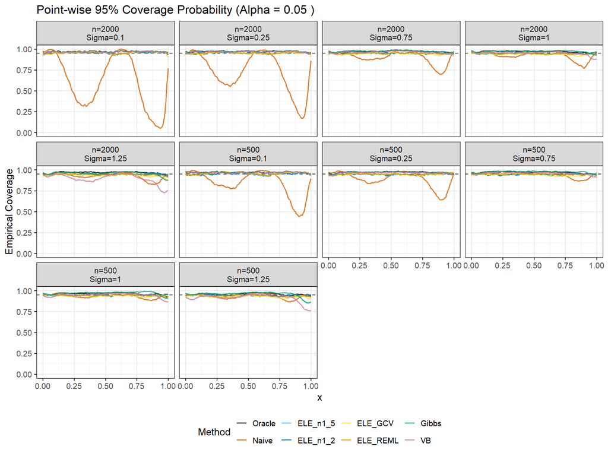

###### Alpha Setting: 0.15

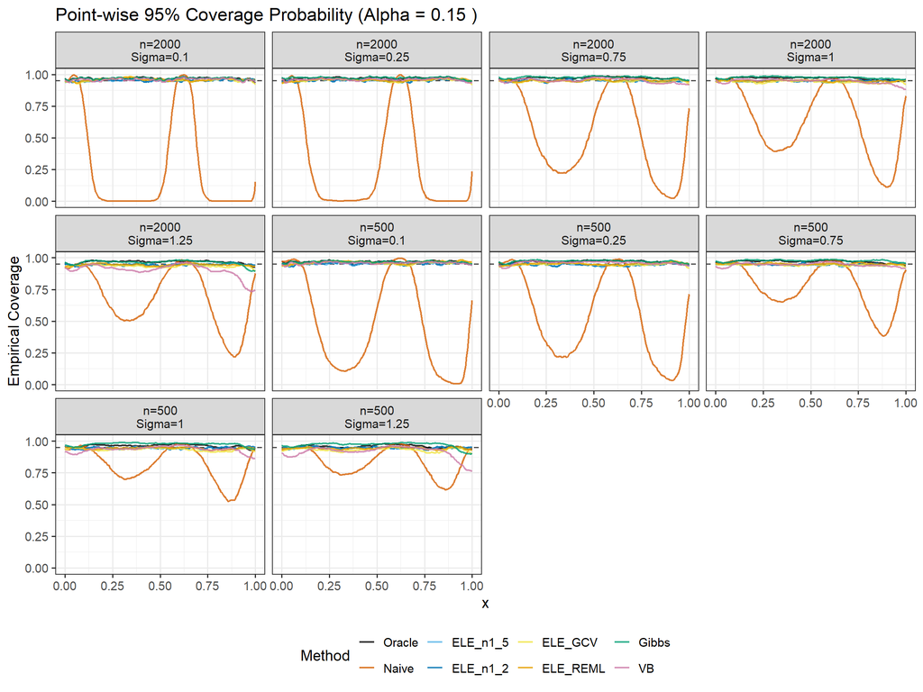

###### Alpha Setting: 0.3

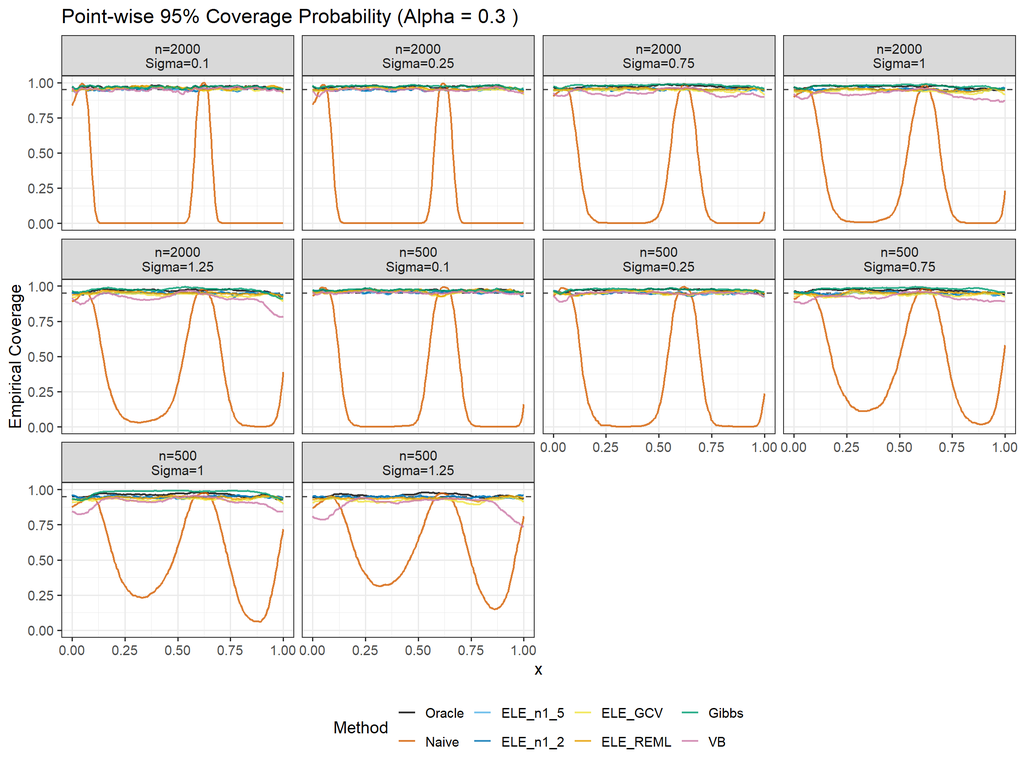

##### (Zoomed)

```r
coverage_profile_zoomed <- raw_sim_data %>%
 filter(Method != "Naive") %>%
 group_by(K, n, sigma_true, Alpha_Setting, Method) %>%
 summarise(across(starts_with("pt_cov_"), mean), .groups = "drop") %>%
 pivot_longer(cols = starts_with("pt_cov_"),
              names_to = "grid_idx",
              values_to = "coverage") %>%
 mutate(
  grid_idx = as.numeric(gsub("pt_cov_", "", grid_idx)),
  x = (grid_idx - 1) / 199,
  Scenario = factor(paste0("n=", n, "\nSigma=", sigma_true)),
  Method = factor(Method, levels = names(method_colors)),
  Alpha_Setting = as.factor(Alpha_Setting)
 )

for(a in unique(coverage_profile_zoomed$Alpha_Setting[coverage_profile_zoomed$K == 1])) {
  cat("###### Alpha Setting: ", a, "\n\n")

  p <- ggplot(coverage_profile_zoomed %>% filter(K == 1, Alpha_Setting == a), aes(x = x, y = coverage, color = Method)) +
   geom_hline(yintercept = 0.95, linetype = "dashed", color = "gray30") +
   geom_line(alpha = 0.8, linewidth = 0.8) +
   facet_wrap(~ Scenario, ncol = 4) +
   scale_color_manual(values = method_colors) +
   theme_bw(base_size = 14) +
   theme(legend.position = "bottom", legend.box = "vertical") +
   labs(title = paste("Point-wise 95% Coverage Probability (Zoomed, Naive Excluded | Alpha =", a, ")"),
        x = "x",
        y = "Empirical Coverage",
        color = "Method") +
   coord_cartesian(ylim = c(0.9, 1.00))

  print(p)
  cat("\n\n")
}
```

###### Alpha Setting: 0.05

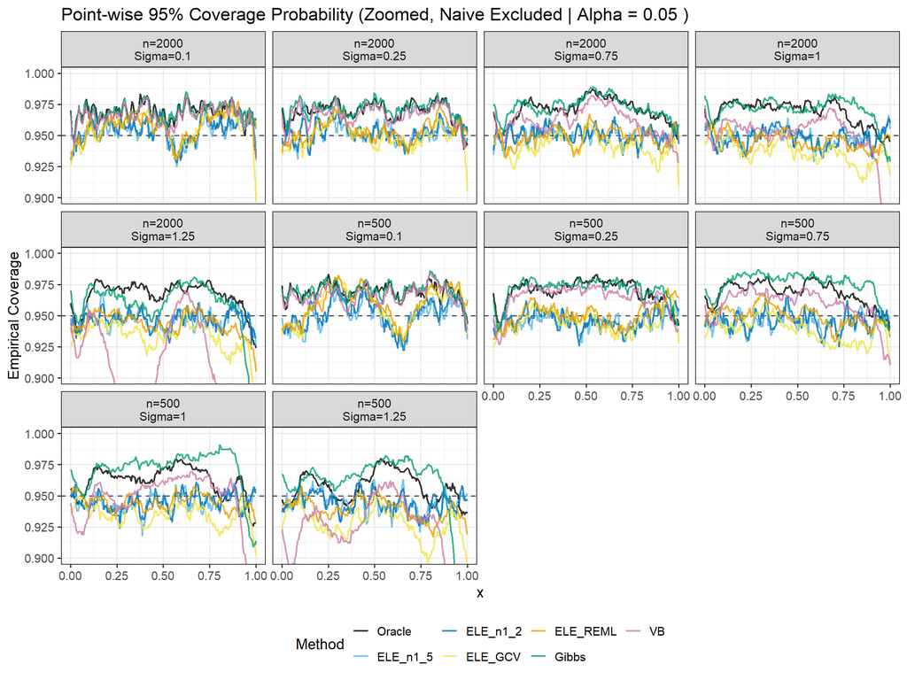

###### Alpha Setting: 0.15

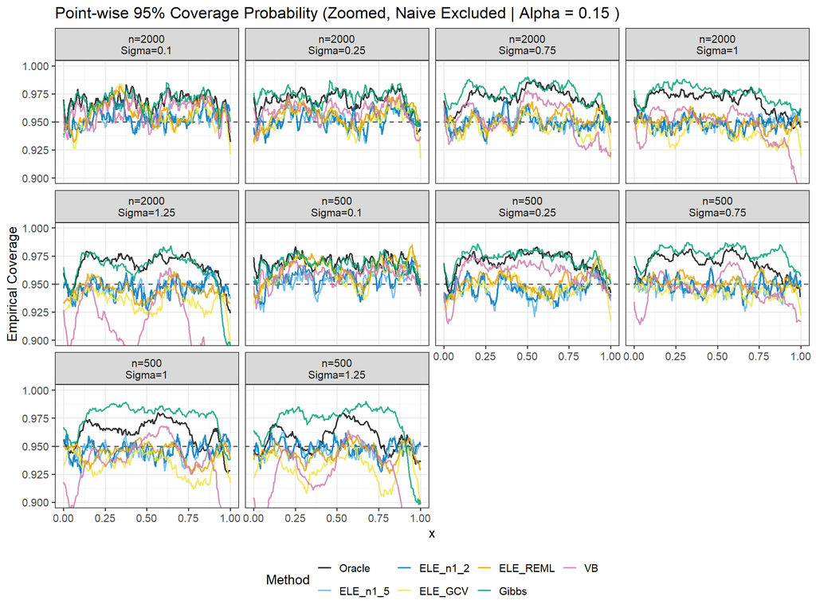

###### Alpha Setting: 0.3

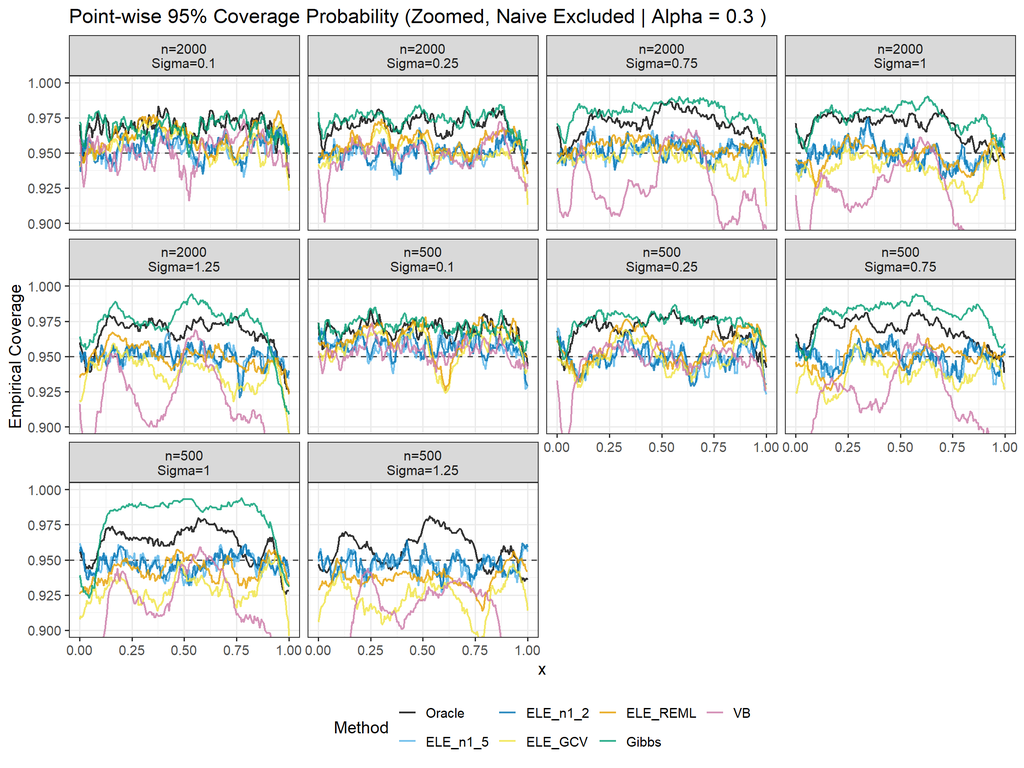

##### Four Blocks, K=4 (Overall)

```r
for(a in unique(coverage_profile$Alpha_Setting[coverage_profile$K == 4])) {
  cat("###### Alpha Setting: ", a, "\n\n")

  p <- ggplot(coverage_profile %>% filter(K == 4, Alpha_Setting == a), aes(x = x, y = coverage, color = Method)) +
   geom_hline(yintercept = 0.95, linetype = "dashed", color = "gray30") +
   geom_line(alpha = 0.8, linewidth = 0.8) +
   facet_wrap(~ Scenario, ncol = 4) +
   scale_color_manual(values = method_colors) +
   theme_bw(base_size = 14) +
   theme(legend.position = "bottom", legend.box = "vertical") +
   labs(title = paste("Point-wise 95% Coverage Probability (Alpha =", a, ")"),
        x = "x",
        y = "Empirical Coverage",
        color = "Method") +
   coord_cartesian(ylim = c(0.0, 1.0))

  print(p)
  cat("\n\n")
}
```

###### Alpha Setting: 0.05_0.1_0.2_0.3

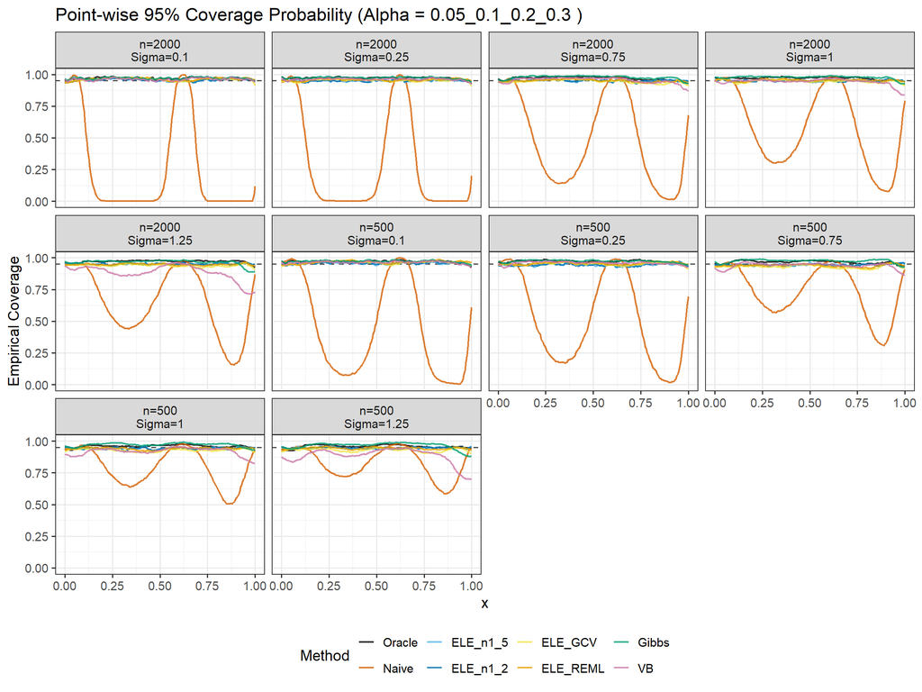

##### (Zoomed)

```r
for(a in unique(coverage_profile_zoomed$Alpha_Setting[coverage_profile_zoomed$K == 4])) {
  cat("###### Alpha Setting: ", a, "\n\n")

  p <- ggplot(coverage_profile_zoomed %>% filter(K == 4, Alpha_Setting == a), aes(x = x, y = coverage, color = Method)) +
   geom_hline(yintercept = 0.95, linetype = "dashed", color = "gray30") +
   geom_line(alpha = 0.8, linewidth = 0.8) +
   facet_wrap(~ Scenario, ncol = 4) +
   scale_color_manual(values = method_colors) +
   theme_bw(base_size = 14) +
   theme(legend.position = "bottom", legend.box = "vertical") +
   labs(title = paste("Point-wise 95% Coverage Probability (Zoomed, Naive Excluded | Alpha =", a, ")"),
        x = "x",
        y = "Empirical Coverage",
        color = "Method") +
   coord_cartesian(ylim = c(0.9, 1.00))

  print(p)
  cat("\n\n")
}
```

###### Alpha Setting: 0.05_0.1_0.2_0.3

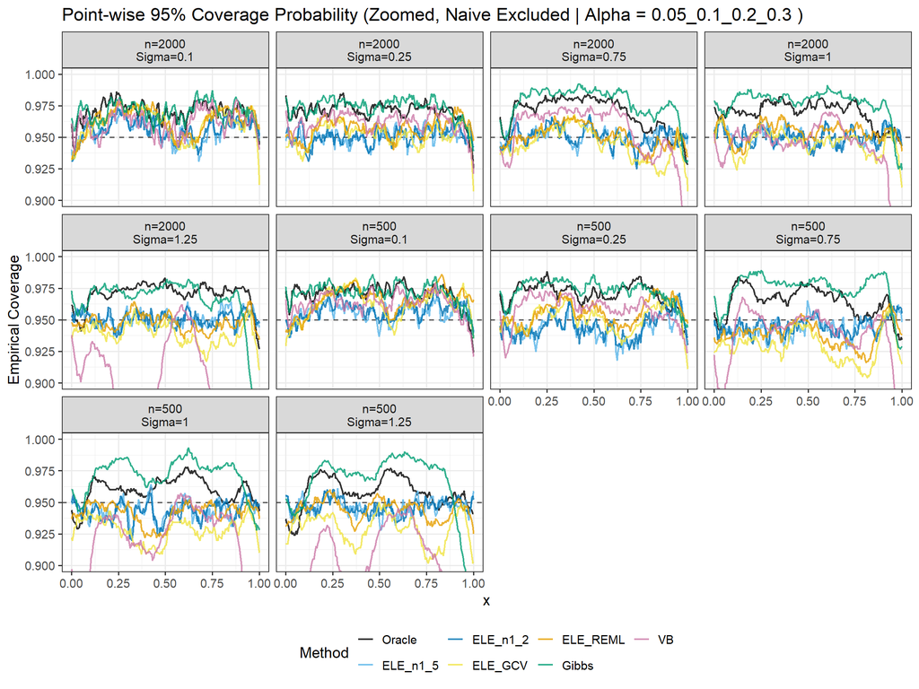

#### RMSE Distribution Boxplots

##### Single Block, K=1

```r
rmse_data <- raw_sim_data %>%
 mutate(
  Scenario = factor(paste0("n=", n, "\nSigma=", sigma_true)),
  Method = factor(Method, levels = names(method_colors)),
  Alpha_Setting = as.factor(Alpha_Setting)
 )

for(a in unique(rmse_data$Alpha_Setting[rmse_data$K == 1])) {
  cat("###### Alpha Setting: ", a, "\n\n")

  p <- ggplot(rmse_data %>% filter(K == 1, Alpha_Setting == a), aes(x = Method, y = RMSE, fill = Method)) +
   geom_boxplot(outlier.alpha = 0.3, outlier.size = 1) +
   facet_wrap(~ Scenario, ncol = 4, scales = "free_y") +
   scale_fill_manual(values = method_colors) +
   scale_y_log10() +
   theme_bw(base_size = 12) +
   theme(axis.text.x = element_text(angle = 45, hjust = 1),
         legend.position = "none") +
   labs(title = paste("Distribution of Function Estimation RMSE (Alpha =", a, ")"),
        x = NULL,
        y = "Root Mean Squared Error (Log10 Scale)")

  print(p)
  cat("\n\n")
}
```

###### Alpha Setting: 0.05

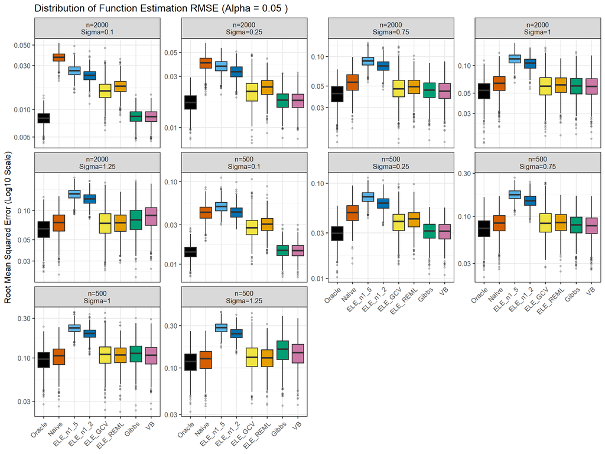

###### Alpha Setting: 0.15

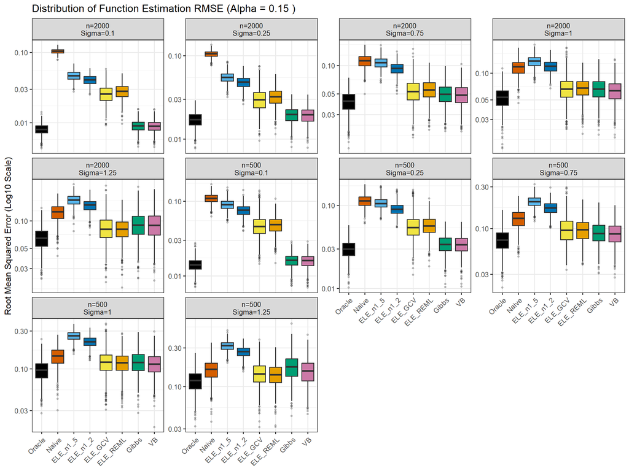

###### Alpha Setting: 0.3

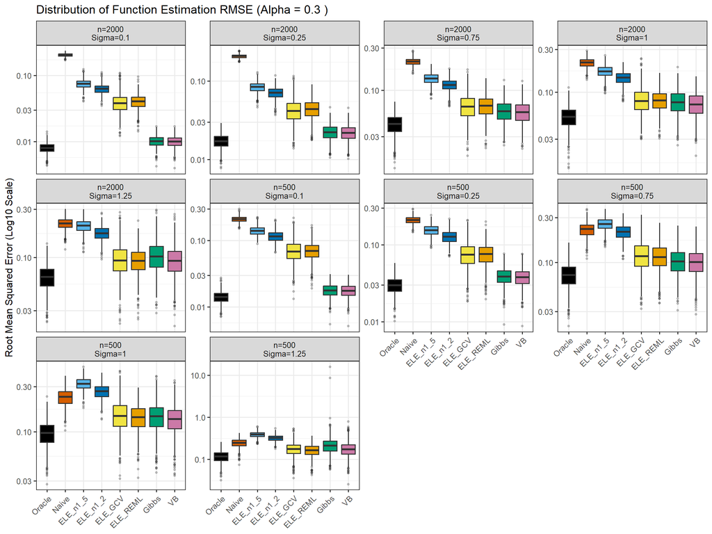

##### Four Blocks, K=4

```r
for(a in unique(rmse_data$Alpha_Setting[rmse_data$K == 4])) {
  cat("###### Alpha Setting: ", a, "\n\n")

  p <- ggplot(rmse_data %>% filter(K == 4, Alpha_Setting == a), aes(x = Method, y = RMSE, fill = Method)) +
   geom_boxplot(outlier.alpha = 0.3, outlier.size = 1) +
   facet_wrap(~ Scenario, ncol = 4, scales = "free_y") +
   scale_fill_manual(values = method_colors) +
   scale_y_log10() +
   theme_bw(base_size = 12) +
   theme(axis.text.x = element_text(angle = 45, hjust = 1),
         legend.position = "none") +
   labs(title = paste("Distribution of Function Estimation RMSE (Alpha =", a, ")"),
        x = NULL,
        y = "Root Mean Squared Error (Log10 Scale)")

  print(p)
  cat("\n\n")
}
```

###### Alpha Setting: 0.05_0.1_0.2_0.3

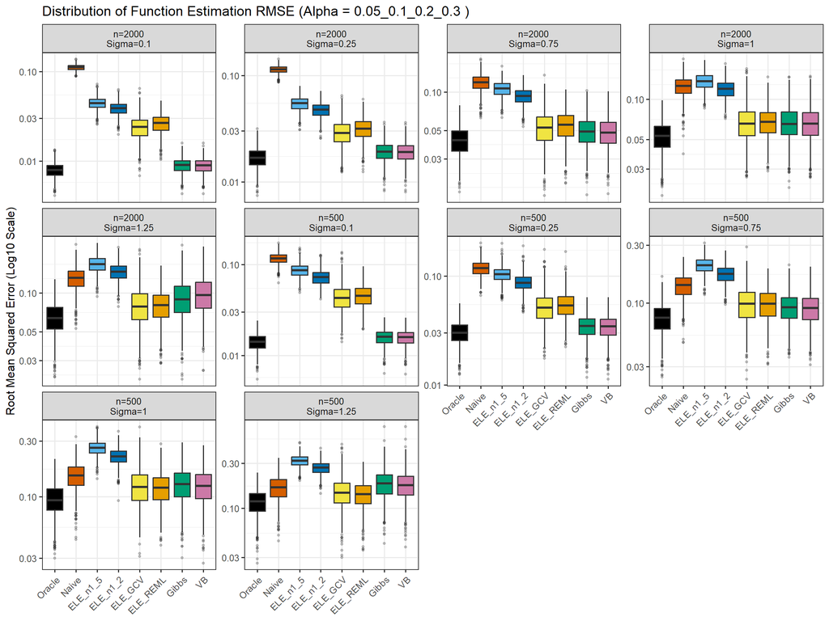

#### RMSE vs. $\sigma_*$

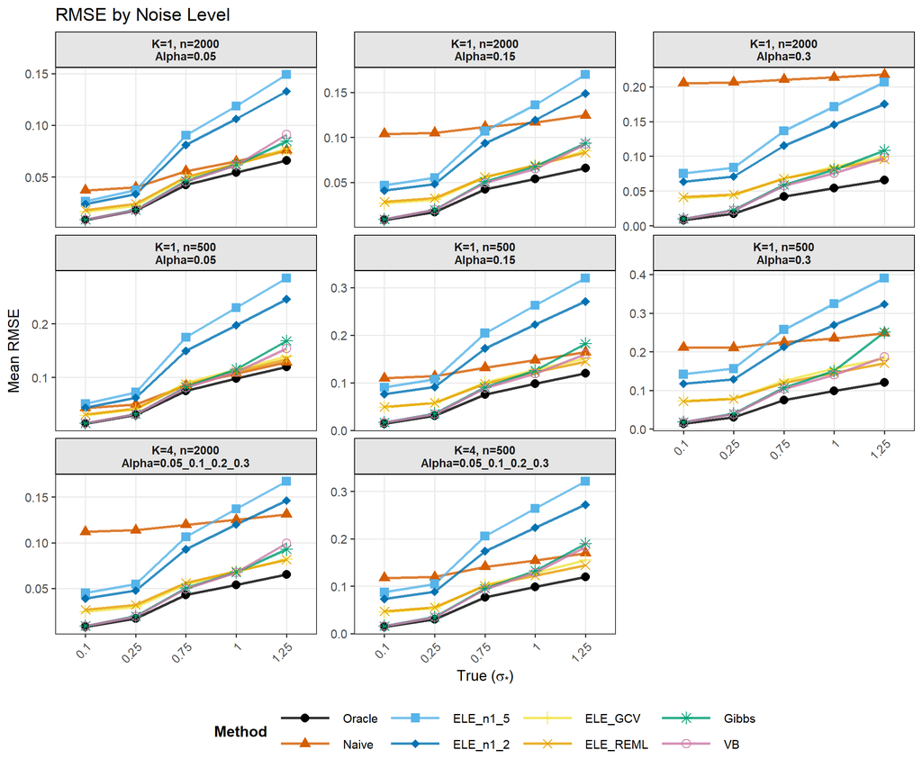

```r
cross_data <- summary_stats %>%
 mutate(
  Scenario = factor(paste0("K=", K, ", n=", n, "\nAlpha=", Alpha_Setting)),
  Method = factor(Method, levels = names(method_colors)),
  sigma_true_factor = factor(sigma_true)
 )

ggplot(cross_data, aes(x = sigma_true_factor, y = Mean_RMSE,
                             color = Method, group = Method, shape = Method)) +
 geom_line(linewidth = 1.2, alpha = 0.8) +
 geom_point(size = 3.5) +

 facet_wrap(~ Scenario, ncol = 3, scales = "free_y") +

 scale_color_manual(values = method_colors) +
 scale_shape_manual(values = c(16, 17, 15, 18, 3, 4, 8, 21)) +

 theme_bw(base_size = 14) +
 theme(
  legend.position = "bottom",
  legend.title = element_text(face = "bold"),
  legend.key.width = unit(2, "cm"),
  strip.background = element_rect(fill = "grey90", color = "black"),
  strip.text = element_text(face = "bold", size = 11),
  panel.grid.minor = element_blank(),
  axis.text.x = element_text(angle = 45, hjust = 1)
 ) +

 labs(
  title = "RMSE by Noise Level",
  x = expression(paste("True (", sigma["*"], ")")),
  y = "Mean RMSE",
  color = "Method",
  shape = "Method"
 )
```

#### Run Time vs. RMSE Trade-off

##### Single Block, K=1

```r
tradeoff_data <- summary_stats %>%
 mutate(
  Scenario = paste0("n=", n, "\nSigma=", sigma_true),
  Method = factor(Method, levels = names(method_colors)),
  Alpha_Setting = as.factor(Alpha_Setting)
 )

for(a in unique(tradeoff_data$Alpha_Setting[tradeoff_data$K == 1])) {
  cat("###### Alpha Setting: ", a, "\n\n")

  p <- ggplot(tradeoff_data %>% filter(K == 1, Alpha_Setting == a), aes(x = Avg_Time_Sec, y = Mean_RMSE, color = Method)) +
   geom_point(size = 3.5, alpha = 0.8) +
   facet_wrap(~ Scenario, ncol = 4, scales = "free") +
   scale_color_manual(values = method_colors) +
   scale_x_log10() +
   scale_y_log10() +
   theme_bw(base_size = 14) +
   theme(legend.position = "bottom", legend.box = "vertical") +
   labs(title = paste("Accuracy vs. Computational Cost Trade-off (Alpha =", a, ")"),
        x = "Average Computation Time (Seconds, Log10 Scale)",
        y = "Mean RMSE (Log10 Scale)",
        color = "Method")
  print(p)
  cat("\n\n")
}
```

###### Alpha Setting: 0.05

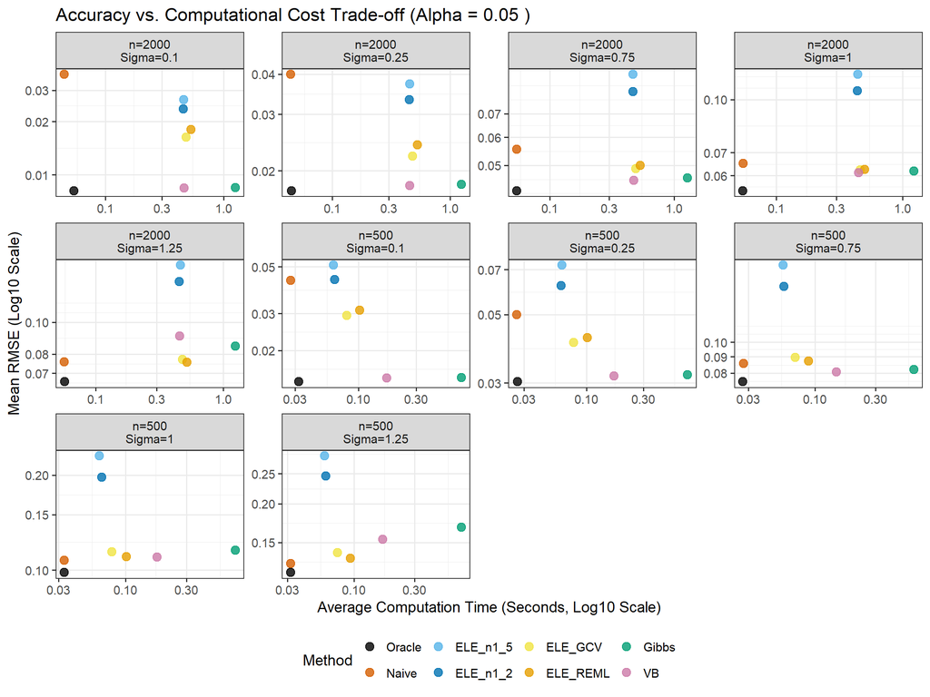

###### Alpha Setting: 0.15

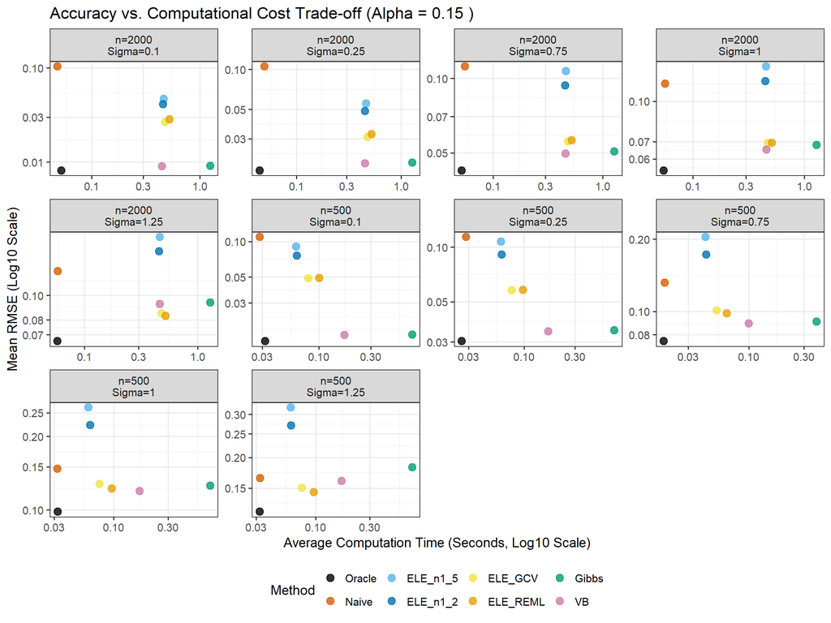

###### Alpha Setting: 0.3

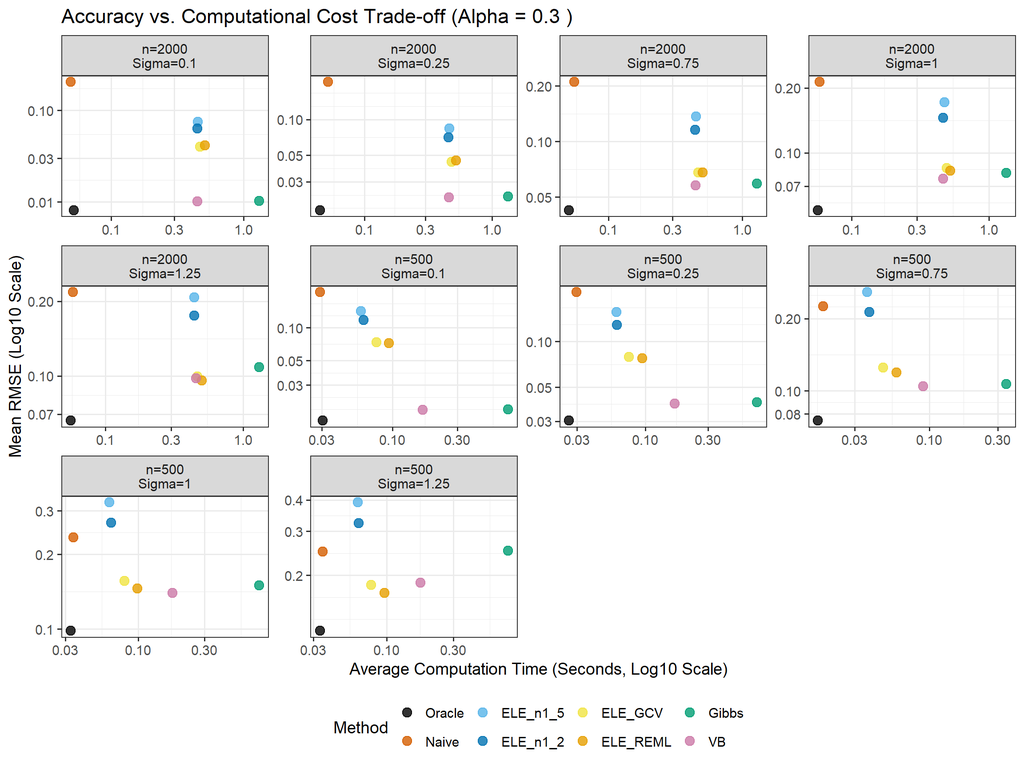

##### Four Blocks, K=4

```r
for(a in unique(tradeoff_data$Alpha_Setting[tradeoff_data$K == 4])) {
  cat("###### Alpha Setting: ", a, "\n\n")

  p <- ggplot(tradeoff_data %>% filter(K == 4, Alpha_Setting == a), aes(x = Avg_Time_Sec, y = Mean_RMSE, color = Method)) +
   geom_point(size = 3.5, alpha = 0.8) +
   facet_wrap(~ Scenario, ncol = 4, scales = "free") +
   scale_color_manual(values = method_colors) +
   scale_x_log10() +
   scale_y_log10() +
   theme_bw(base_size = 14) +
   theme(legend.position = "bottom", legend.box = "vertical") +
   labs(title = paste("Accuracy vs. Computational Cost Trade-off (Alpha =", a, ")"),
        x = "Average Computation Time (Seconds, Log10 Scale)",
        y = "Mean RMSE (Log10 Scale)",
        color = "Method")
  print(p)
  cat("\n\n")
}
```

###### Alpha Setting: 0.05_0.1_0.2_0.3

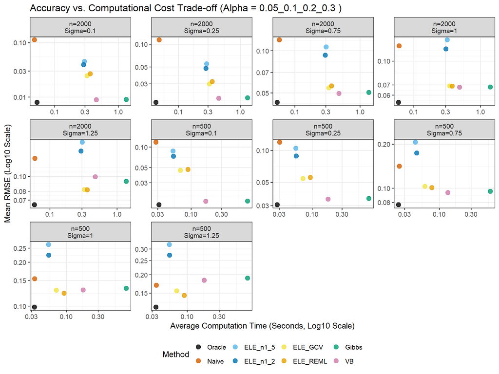

## Appendix

### HPC Script

```bash
#!/bin/bash
#SBATCH --job-name=spline_sim
#SBATCH --output=logs/sim_%A_%a.out
#SBATCH --error=logs/sim_%A_%a.err
#SBATCH --array=1-400
#SBATCH --time=01:00:00
#SBATCH --cpus-per-task=1
#SBATCH --mem=2G
#SBATCH --partition=standard

module load goolf R

mkdir -p logs
mkdir -p sim_results

Rscript Spline_Simulations.R
```

### R Script

```r
# ******************************************************************************
# Spline Regression with Mismatch Error
# ******************************************************************************
.libPaths("~/R/hpc_libs")

library(mgcv)
library(MASS)
library(Matrix)

# 1. ELE Permutation Helpers (Model II)
# ------------------------------------------------------------------------------
# random permutation with no fixed point (zero diagonal entries)
get_perm <- function(n_items) {
 if (n_items == 0) return(integer(0))
 if (n_items == 1) return(1)
 x <- 1:n_items
 while (TRUE) {
  px <- sample(x)
  if (all(px != x)) return(px)
 }
}

# 2. Simulation Configuration & Grid
# ------------------------------------------------------------------------------
N_REPS <- 1000

# Define scenarios (K=1 block and K=4 blocks)
scenarios <- list()

for (n in c(500, 2000)) {
 for (sigma in c(0.1, 0.25, 0.75, 1, 1.25)) {
  # K = 1 scenarios
  for (a in c(0.05, 0.15, 0.3)) {
   scenarios[[length(scenarios) + 1]] <- list(
    n = n, sigma = sigma, K = 1, alphas = a
   )
  }
  # K = 4 scenario
  scenarios[[length(scenarios) + 1]] <- list(
   n = n, sigma = sigma, K = 4, alphas = c(0.05, 0.1, 0.2, 0.3)
  )
 }
}

eval_grid <- data.frame(x = seq(0, 1, length.out = 200))
true_f_eval <- sin(1.5 * pi * eval_grid$x)

# 3. Data Generation Process (w/ Block Permutation Logic)
# ------------------------------------------------------------------------------
generate_data <- function(n, sigma, K, alphas, rep_id, global_seed) {
 base_seed <- rep_id * 10000 + n + K * 100 + as.integer(sigma * 100)
 set.seed(base_seed)

 # Generate true X equally spaced
 x <- seq(0, 1, length.out = n)

 # Randomly assign records to K blocks
 Block <- sample(rep(1:K, each = n/K))

 # Generate True Signal and True Y
 f_true <- sin(1.5 * pi * x)
 Y <- rnorm(n, f_true, sigma)
 z <- rnorm(n, 0, 1)

 M <- c(table(Block)) # block sizes
 Ystar <- numeric(n)
 m_true <- numeric(n)

 set.seed(global_seed)

 # Permute Y to get Ystar (with linkage errors via Model II)
 for(q in 1:K) {
  idx <- which(Block == q)
  mq <- M[q]

  n_mismatch <- round(mq * alphas[q])

  if(n_mismatch > 0) {
   mis_idx_relative <- sample(1:mq, n_mismatch)
   perm_relative <- mis_idx_relative[get_perm(n_mismatch)]

   y_block <- Y[idx]
   y_shuffled <- y_block
   y_shuffled[mis_idx_relative] <- y_block[perm_relative]

   Ystar[idx] <- y_shuffled
   m_true[idx[mis_idx_relative]] <- 1 # m_i = I(Pi_ii != 1)
  } else {
   Ystar[idx] <- Y[idx]
  }
 }

 ord <- order(Block)

 list(x = x[ord], y_obs = Ystar[ord], y_true = Y[ord], z = z[ord],
      blocks = Block[ord], m = m_true[ord], f_true = f_true[ord])
}

# 4. Model Estimation Wrappers
# ------------------------------------------------------------------------------
build_Q_matrix <- function(n, K, blocks, alphas) {
 Q_list <- lapply(1:K, function(k) {
  nk <- sum(blocks == k)
  ak <- alphas[k]
  if (ak == 0) return(diag(nk))
  (1 - ak - ak/(nk - 1)) * diag(nk) + (ak/(nk - 1)) * matrix(1, nk, nk)
 })
 as.matrix(bdiag(Q_list))
}

# ELE Approach
fit_ele <- function(dat, K, alphas, sp_choice, sigma_true, eval_grid) {
 n <- length(dat$y_obs)

 gam_naive <- gam(y_obs ~ s(x, bs="cr", k=25), data = dat)
 gamobj <- gam(y_obs ~ s(x, bs="cr", k=25, fx=FALSE), data = dat, fit = FALSE)

 X <- as.matrix(gamobj$X)[, -1]
 xc <- dat$x - mean(dat$x)

 P <- gamobj$smooth[[1]]$S[[1]]
 svdP <- svd(P)
 rankthres <- 1e-8
 rankP <- sum(svdP$d > rankthres)
 Rinv <- svdP$v[, 1:rankP] %*% diag(1/sqrt(svdP$d[1:rankP])) %*% t(svdP$u[, 1:rankP])

 Q <- build_Q_matrix(n, K, dat$blocks, alphas)
 Qxc <- Q %*% xc
 QX <- Q %*% X

 Z_Q <- residuals(lm(QX ~ Qxc))
 Z_Qtilde <- Z_Q %*% Rinv

 svdZ <- svd(Z_Qtilde)
 rankZ <- sum(svdZ$d > rankthres)
 VQr <- svdZ$v[, 1:rankZ]
 DQr <- svdZ$d[1:rankZ]
 UQr <- svdZ$u[, 1:rankZ]

 ypermtilde <- residuals(lm(dat$y_obs ~ Qxc))

 if (is.character(sp_choice)) {
  ele_dat <- data.frame(y_tilde = as.numeric(ypermtilde))
  ele_dat$Z <- Z_Qtilde

  mgcv_method <- ifelse(sp_choice == "GCV", "GCV.Cp", "REML")
  mgcv_fit <- gam(y_tilde ~ -1 + Z,
                  data = ele_dat,
                  paraPen = list(Z = list(diag(1, ncol(Z_Qtilde)))),
                  method = mgcv_method)

  sp <- as.numeric(mgcv_fit$sp)
 } else if (is.numeric(sp_choice)) {
  sp <- sp_choice
 } else {
  stop("Invalid sp_choice provided.")
 }

 L <- solve(crossprod(Z_Qtilde) + sp * diag(1, ncol(Z_Qtilde)))
 alphahat <- L %*% crossprod(Z_Qtilde, ypermtilde)

 alphahat_db <- alphahat + sp * drop(VQr %*% (drop(crossprod(VQr, alphahat)) / (DQr^2 + sp)))
 betahat_db <- Rinv %*% alphahat_db

 # Based on (Eq 12)
 tilde_f <- as.numeric(X %*% betahat_db -
                        xc * drop(crossprod(Qxc, QX %*% betahat_db)) / sum(Qxc^2) +
                        xc * coef(lm(dat$y_obs ~ Qxc))[2] +
                        mean(dat$y_obs))

 rss <- sum((dat$y_obs - tilde_f)^2)
 penalty_term <- 2 * sum(tilde_f * (as.numeric((diag(n) - Q) %*% tilde_f)))

 sig2_est <- (rss - penalty_term) / n
 sig2_est <- max(sig2_est, 1e-6)

 X_eval <- predict(gam_naive, newdata = eval_grid, type = "lpmatrix")[, -1]
 xc_eval <- eval_grid$x - mean(dat$x)

 f_est <- as.numeric(X_eval %*% betahat_db -
                      xc_eval * drop(crossprod(Qxc, QX %*% betahat_db)) / sum(Qxc^2) +
                      xc_eval * coef(lm(dat$y_obs ~ Qxc))[2] +
                      mean(dat$y_obs))

 D <- numeric(n)
 for (i in 1:n) {
  k <- dat$blocks[i]
  ak <- alphas[k]
  if(ak > 0) {
   idx_k <- which(dat$blocks == k)
   mu_k <- tilde_f[idx_k]
   i_in_k <- which(idx_k == i)

   mu_i <- mu_k[i_in_k]
   mu_m_i <- mu_k[-i_in_k]

   D[i] <- ((1-ak) - (1-ak)^2)*mu_i^2 + ak*mean(mu_m_i^2) -
    ak^2*mean(mu_m_i)^2 - 2*ak*(1-ak)*mu_i*mean(mu_m_i)
  }
 }

 A <- VQr %*% diag(sp / (DQr^2 + sp)) %*% t(VQr)
 A <- A + diag(1, nrow(A))

 Xtilde_eval <- X_eval - (as.matrix(xc_eval) %*% crossprod(Qxc, QX)) / sum(Qxc^2)

 A_mat <- Xtilde_eval %*% Rinv %*% A %*% L %*% t(Z_Qtilde)
 B_mat <- cbind(1, xc_eval) %*% solve(crossprod(cbind(1, Qxc))) %*% t(cbind(1, Qxc))
```

```r
 var_vec <- as.numeric((A_mat^2) %*% (D + sig2_est) +
                        (B_mat^2) %*% (D + sig2_est) +
                        2 * (A_mat * B_mat) %*% (D + sig2_est))

 lower <- f_est - sqrt(var_vec) * qnorm(0.975)
 upper <- f_est + sqrt(var_vec) * qnorm(0.975)

 return(list(f_est = f_est, lower = lower, upper = upper, sigma = sqrt(sig2_est)))
}

# Gibbs Approach - Updated For K-Blocks According to ELE Assumption
fit_gibbs <- function(dat, K, n_iter = 1500, burn_in = 500) {
 t0 <- Sys.time()

 df <- data.frame(x = dat$x, y = dat$y_obs)
 formula <- y ~ s(x, bs="cr", k=25)
 blocks <- dat$blocks

 gam_naive <- gam(formula, data = df)
 gamobj <- gam(formula, data = df, fit = FALSE)

 beta_naive <- as.numeric(coef(gam_naive))
 n <- length(dat$y_obs)
 y <- dat$y_obs

 Bgam <- as.matrix(gamobj$X)
 Sgam <- rbind(0, cbind(0, gamobj$smooth[[1]]$S[[1]]))

 d <- ncol(Bgam)
 rank_S <- sum(abs(eigen(Sgam, symmetric = TRUE, only.values = TRUE)$values) > 1e-8)

 kdeobj <- density(y)
 kdefun <- approxfun(kdeobj$x, kdeobj$y, method = "constant", rule = 2)
 fy_vals <- pmax(kdefun(y), 1e-10)

 XtX_total <- crossprod(Bgam)
 Xty_total <- crossprod(Bgam, y)

 m <- rep(0, n)
 alpha <- rep(0.1, K)
 beta <- beta_naive
 sigma2 <- var(y) * 0.5
 tau2 <- 1

 n_save <- n_iter - burn_in
 samples_beta <- matrix(0, n_save, d)
 samples_alpha <- matrix(0, n_save, K)
 samples_sigma2 <- numeric(n_save)
 samples_tau2 <- numeric(n_save)
 sum_m_probs <- rep(0, n)

 n_k <- sapply(1:K, function(k) sum(blocks == k))

 # Gibbs Loop
 for (iter in 1:n_iter) {

  mu_curr <- as.vector(Bgam %*% beta)
  lik_correct <- dnorm(y, mean = mu_curr, sd = sqrt(sigma2))

  prob_prior <- alpha[blocks]

  num <- fy_vals * prob_prior
  den <- num + lik_correct * (1 - prob_prior)
  prob_m1 <- num / (den + 1e-300)

  m <- rbinom(n, 1, prob_m1)

  sum_m_k <- sapply(1:K, function(k) sum(m[blocks == k]))
  alpha <- rbeta(K, 1 + sum_m_k, 1 + n_k - sum_m_k)

  idx_m <- which(m == 1)
  XtX_c <- XtX_total
  Xty_c <- Xty_total

  if (length(idx_m) > 0) {
   Bm <- Bgam[idx_m, , drop = FALSE]
   ym <- y[idx_m]
   XtX_c <- XtX_c - crossprod(Bm)
   Xty_c <- Xty_c - crossprod(Bm, ym)
  }

  Q <- (XtX_c / sigma2) + (Sgam / tau2)
  diag(Q) <- diag(Q) + 1e-6

  rhs <- Xty_c / sigma2
  L <- tryCatch(chol(Q), error = function(e) NULL)

  if (!is.null(L)) {
   mu_beta <- backsolve(L, forwardsolve(t(L), rhs))
   z <- rnorm(d)
   beta <- mu_beta + backsolve(L, z)
  } else {
   beta <- rep(0, d)
  }

  idx_c <- which(m == 0)
  if (length(idx_c) > 0) {
   resid <- y[idx_c] - as.vector(Bgam[idx_c, , drop = FALSE] %*% beta)
   sse <- sum(resid^2)
   sigma2 <- 1 / rgamma(1, shape = length(idx_c)/2, rate = sse/2)
  }

  roughness <- as.numeric(t(beta) %*% Sgam %*% beta)
  tau2 <- 1 / rgamma(1, shape = rank_S/2, rate = roughness/2)

  if (iter > burn_in) {
   idx <- iter - burn_in
   samples_beta[idx, ] <- beta
   samples_alpha[idx, ] <- alpha
   samples_sigma2[idx] <- sigma2
   samples_tau2[idx] <- tau2
   sum_m_probs <- sum_m_probs + m
  }
 }

 beta_hat <- colMeans(samples_beta)
 alpha_hat <- colMeans(samples_alpha)
 sigma_hat <- sqrt(mean(samples_sigma2))
 tau2_hat <- mean(samples_tau2)
 m_probs_hat <- sum_m_probs / n_save

 X_eval <- predict(gam_naive, newdata = eval_grid, type = "lpmatrix")
 f_est <- as.numeric(X_eval %*% beta_hat)

 f_samples <- X_eval %*% t(samples_beta)
 lower <- apply(f_samples, 1, quantile, probs = 0.025)
 upper <- apply(f_samples, 1, quantile, probs = 0.975)

 sigma_ci_lower <- sqrt(quantile(samples_sigma2, 0.025))
 sigma_ci_upper <- sqrt(quantile(samples_sigma2, 0.975))

 tau2_ci_lower <- quantile(samples_tau2, 0.025)
 tau2_ci_upper <- quantile(samples_tau2, 0.975)

 alpha_ci_lower <- apply(samples_alpha, 2, quantile, probs = 0.025)
 alpha_ci_upper <- apply(samples_alpha, 2, quantile, probs = 0.975)

 time_elapsed <- as.numeric(Sys.time() - t0)

 return(list(
  f_est = f_est, lower = lower, upper = upper,
  sigma = sigma_hat, sigma_ci_lower = sigma_ci_lower, sigma_ci_upper = sigma_ci_upper,
  alpha = alpha_hat, alpha_ci_lower = alpha_ci_lower, alpha_ci_upper = alpha_ci_upper,
  tau2 = tau2_hat, tau2_ci_lower = tau2_ci_lower, tau2_ci_upper = tau2_ci_upper,
  m_probs = m_probs_hat, time = time_elapsed
 ))
}

# Variational Inference - Updated for K-Blocks According to ELE Asusmption
# ------------------------------------------------------------------------------
fit_vi <- function(dat, K, maxiter = 100) {
 t0 <- Sys.time()

 df <- data.frame(x = dat$x, y = dat$y_obs)
 formula <- y ~ s(x, bs="cr", k=25)
 blocks <- dat$blocks

 gam_naive <- gam(formula, data = df)
 gamobj <- gam(formula, data = df, fit = FALSE)

 beta_naive <- coef(gam_naive)
 n <- length(gam_naive$fitted.values)

 Sgam <- rbind(0, cbind(0, gamobj$smooth[[1]]$S[[1]]))
 Bgam <- as.matrix(gamobj$X)

 d <- ncol(Bgam)
 d_null <- sum(svd(Sgam)$d < sqrt(.Machine$double.eps))
 dstar <- d - d_null

 y <- df$y
 kdeobj <- density(y)
 kdefun <- approxfun(kdeobj$x, kdeobj$y, method = "constant", rule = 2)
 fy <- kdefun(y)

 par_beta <- list(mu = beta_naive, Prec = crossprod(Bgam))
 par_sigmasq <- list(shape = (n - d)/2, rate = sum(residuals(gam_naive)^2)/2)
 par_pi <- list(a = rep(1, K), b = rep(1, K))
 par_tausq <- list(shape = dstar/2, rate = sum(beta_naive * (Sgam %*% beta_naive)) / 2)

 n_k <- sapply(1:K, function(k) sum(blocks == k))

 # Coordinate Ascent Loop
 for(ii in 1:maxiter) {

  E_log_pi_a_k <- digamma(par_pi$a) - digamma(par_pi$a + par_pi$b)
  E_log_pi_b_k <- digamma(par_pi$b) - digamma(par_pi$a + par_pi$b)

  E_log_pi_a_obs <- E_log_pi_a_k[blocks]
  E_log_pi_b_obs <- E_log_pi_b_k[blocks]

  log_prob_mm_unnorm <- E_log_pi_a_obs + log(fy)

  E_reciproc_sigmasq <- par_sigmasq$shape / par_sigmasq$rate
  E_fit <- Bgam %*% par_beta$mu

  invPrec_B <- t(solve(par_beta$Prec, t(Bgam)))
  E_Quad <- rowSums(Bgam * invPrec_B) + (E_fit^2) * E_reciproc_sigmasq

  E_log_reciproc_sigmasq <- digamma(par_sigmasq$shape) - log(par_sigmasq$rate)
  log_prob_cm_unnorm <- E_log_pi_b_obs - 0.5*(y^2 - 2*y * E_fit)*E_reciproc_sigmasq -
   0.5*log(2*pi) + 0.5 * E_log_reciproc_sigmasq - 0.5*E_Quad
```

```r
  logpmax <- pmax(log_prob_mm_unnorm, log_prob_cm_unnorm)
  logsumexp <- logpmax + log(exp(log_prob_mm_unnorm - logpmax) + exp(log_prob_cm_unnorm - logpmax))
  par_m <- exp(log_prob_mm_unnorm - logsumexp)

  sum_m_k <- sapply(1:K, function(k) sum(par_m[blocks == k]))

  par_pi$a <- 1 + sum_m_k
  par_pi$b <- 1 + n_k - sum_m_k

  reg_weights <- 1 - par_m
  Prec_upd <- crossprod(Bgam, sweep(Bgam, MARGIN = 1, STATS = reg_weights, FUN = "*"))

  E_reciproc_tausq <- par_tausq$shape / par_tausq$rate
  E_lambda <- (1/E_reciproc_sigmasq) * E_reciproc_tausq
  Prec_upd <- Prec_upd + E_lambda * Sgam
  mu_upd <- solve(Prec_upd, crossprod(Bgam, reg_weights * y))

  par_beta$Prec <- Prec_upd
  par_beta$mu <- as.numeric(mu_upd)

  par_sigmasq$shape <- sum(reg_weights)/2
  invPrec_upd_B <- t(solve(Prec_upd, t(Bgam)))
  trace_term <- rowSums(Bgam * invPrec_upd_B)

  par_sigmasq$rate <- sum(reg_weights * ((y - as.numeric(Bgam %*% mu_upd))^2 +
                                          (1/E_reciproc_sigmasq) * trace_term)) / 2

  par_tausq$rate <- (sum(Sgam * solve(Prec_upd)) * (1/E_reciproc_sigmasq) +
                      sum(mu_upd * (Sgam %*% mu_upd))) / 2
 }

 Sigma_beta <- solve(par_beta$Prec) * (1 / (par_sigmasq$shape / par_sigmasq$rate))

 X_eval <- predict(gam_naive, newdata = eval_grid, type = "lpmatrix")
 f_est <- as.numeric(X_eval %*% par_beta$mu)

 se_f <- sqrt(rowSums((X_eval %*% Sigma_beta) * X_eval))
 lower <- f_est - 1.96 * se_f
 upper <- f_est + 1.96 * se_f

 sigma_est <- sqrt(par_sigmasq$rate / (par_sigmasq$shape - 1))
 tau2_est <- par_tausq$rate / (par_tausq$shape - 1)

 alpha_est <- par_pi$a / (par_pi$a + par_pi$b)

 sigma_ci_lower <- sqrt(qgamma(0.975, shape=par_sigmasq$shape, rate=par_sigmasq$rate)^-1)
 sigma_ci_upper <- sqrt(qgamma(0.025, shape=par_sigmasq$shape, rate=par_sigmasq$rate)^-1)

 tau2_ci_lower <- qgamma(0.975, shape=par_tausq$shape, rate=par_tausq$rate)^-1
 tau2_ci_upper <- qgamma(0.025, shape=par_tausq$shape, rate=par_tausq$rate)^-1

 alpha_ci_lower <- qbeta(0.025, par_pi$a, par_pi$b)
 alpha_ci_upper <- qbeta(0.975, par_pi$a, par_pi$b)

 time_elapsed <- as.numeric(Sys.time() - t0)

 return(list(
  f_est = f_est, lower = lower, upper = upper,
  sigma = sigma_est, sigma_ci_lower = sigma_ci_lower, sigma_ci_upper = sigma_ci_upper,
  alpha = alpha_est, alpha_ci_lower = alpha_ci_lower, alpha_ci_upper = alpha_ci_upper,
  tau2 = tau2_est, tau2_ci_lower = tau2_ci_lower, tau2_ci_upper = tau2_ci_upper,
  m_probs = as.numeric(par_m), time = time_elapsed
 ))
}

# Simulation Worker
# ------------------------------------------------------------------------------
run_replication <- function(sim_id, param, global_seed) {
 set.seed(global_seed)

 dat <- generate_data(param$n, param$sigma, param$K, param$alphas, rep_id = sim_id, global_seed = global_seed)
 sim_dat <- data.frame(x = dat$x, y_obs = dat$y_obs, y_true = dat$y_true, z = dat$z)

 res_list <- list()

 # Helper function to isolate methods and track failures
 safe_run <- function(name, expr) {
  t0 <- Sys.time()
  tryCatch({
   res <- eval(expr)
   c(list(Method=name), res, list(time=as.numeric(Sys.time()-t0), Failed=0))
  }, error = function(e) {
   list(Method=name, f_est=rep(NA, 200), lower=rep(NA, 200), upper=rep(NA, 200),
        sigma=NA, sigma_ci_lower=NA, sigma_ci_upper=NA,
        alpha=rep(NA, param$K), alpha_ci_lower=rep(NA, param$K), alpha_ci_upper=rep(NA, param$K),
        tau2=NA, tau2_ci_lower=NA, tau2_ci_upper=NA,
        m_probs=rep(NA, length(dat$y_obs)), time=as.numeric(Sys.time()-t0), Failed=1)
  })
 }

 # Oracle Baseline
 res_list[[1]] <- safe_run("Oracle", {
  fit <- gam(y_true ~ s(x, bs="cr", k=25), data = sim_dat, method="REML")
  p <- predict(fit, newdata = eval_grid, se.fit=TRUE)
  list(f_est=p$fit, lower=p$fit - 1.96*p$se.fit, upper=p$fit + 1.96*p$se.fit)
 })

 # Naive Baseline
 res_list[[2]] <- safe_run("Naive", {
  fit <- gam(y_obs ~ s(x, bs="cr", k=25), data = sim_dat, method="REML")
  p <- predict(fit, newdata = eval_grid, se.fit=TRUE)
  list(f_est=p$fit, lower=p$fit - 1.96*p$se.fit, upper=p$fit + 1.96*p$se.fit)
 })

 # ELE Adjustment Strategies
 ele_strategies <- list("ELE_n1_5" = param$n^(1/5), "ELE_n1_2" = param$n^(1/2), "ELE_GCV" = "GCV", "ELE_REML" = "REML")
 idx <- 3
 for (strat_name in names(ele_strategies)) {
  res_list[[idx]] <- safe_run(strat_name, { fit_ele(dat, param$K, param$alphas, sp_choice = ele_strategies[[strat_name]], sigma_true = param$sigma, eval_grid = eval_grid) })
  idx <- idx + 1
 }

 # Gibbs Sampler
 res_list[[idx]] <- safe_run("Gibbs", { fit_gibbs(dat, param$K) })
 idx <- idx + 1

 # Variational Inference
 res_list[[idx]] <- safe_run("VB", { fit_vi(dat, param$K) })

 # Compile Metrics
 fit_oracle_true <- gam(y_true ~ s(x, bs="cr", k=25), data = sim_dat, method="REML")
 oracle_beta <- coef(fit_oracle_true)
 Sgam_oracle <- rbind(0, cbind(0, fit_oracle_true$smooth[[1]]$S[[1]]))
 # true_tau2 using the Oracle fit to align with mgcv's internal penalty scaling
 # The penalty matrix rank for bs="cr" with k=25 is 23
 true_tau2 <- as.numeric(t(oracle_beta) %*% Sgam_oracle %*% oracle_beta) / 23

 metrics <- lapply(res_list, function(res) {
  if (res$Failed == 1) {
   df_base <- data.frame(
    n = param$n, sigma_true = param$sigma, K = param$K, Alpha_Setting = paste(param$alphas, collapse = "_"),
    Method = res$Method, RMSE = NA, Coverage = NA, Bias_Sigma = NA, Cov_Sigma = NA,
    Bias_Alpha_1 = NA, Cov_Alpha_1 = NA, Bias_Alpha_2 = NA, Cov_Alpha_2 = NA,
    Bias_Alpha_3 = NA, Cov_Alpha_3 = NA, Bias_Alpha_4 = NA, Cov_Alpha_4 = NA,
    Tau2_Est = NA, Bias_Tau2 = NA, Cov_Tau2 = NA, Time = res$time, Failed = 1
   )
   pt_df <- as.data.frame(t(rep(NA, 200)))
   colnames(pt_df) <- paste0("pt_cov_", 1:200)
   return(cbind(df_base, pt_df))
  }

  # Get a 200-point logical vector for true point-wise coverage tracking
  rmse <- sqrt(mean((res$f_est - true_f_eval)^2))
  pt_coverage <- as.numeric(res$lower <= true_f_eval & res$upper >= true_f_eval)
  coverage_mean <- mean(pt_coverage, na.rm=TRUE)
```

```r
  bias_sigma <- if (!is.null(res$sigma)) res$sigma - param$sigma else NA
  cov_sigma <- if (!is.null(res$sigma_ci_lower)) as.numeric(param$sigma >= res$sigma_ci_lower & param$sigma <= res$sigma_ci_upper) else NA

  bias_alpha <- rep(NA, 4); cov_alpha <- rep(NA, 4)
  if (!is.null(res$alpha)) {
   for (k in 1:param$K) {
    bias_alpha[k] <- res$alpha[k] - param$alphas[k]
    if (!is.null(res$alpha_ci_lower)) cov_alpha[k] <- as.numeric(param$alphas[k] >= res$alpha_ci_lower[k] & param$alphas[k] <= res$alpha_ci_upper[k])
   }
  }

  tau2_est <- if(!is.null(res$tau2)) res$tau2 else NA
  bias_tau2 <- if(!is.null(res$tau2)) res$tau2 - true_tau2 else NA
  cov_tau2 <- if(!is.null(res$tau2_ci_lower)) as.numeric(true_tau2 >= res$tau2_ci_lower & true_tau2 <= res$tau2_ci_upper) else NA

  df_base <- data.frame(
   n = param$n, sigma_true = param$sigma, K = param$K, Alpha_Setting = paste(param$alphas, collapse = "_"),
   Method = res$Method, RMSE = rmse, Coverage = coverage_mean, Bias_Sigma = bias_sigma, Cov_Sigma = cov_sigma,
   Bias_Alpha_1 = bias_alpha[1], Cov_Alpha_1 = cov_alpha[1], Bias_Alpha_2 = bias_alpha[2], Cov_Alpha_2 = cov_alpha[2],
   Bias_Alpha_3 = bias_alpha[3], Cov_Alpha_3 = cov_alpha[3], Bias_Alpha_4 = bias_alpha[4], Cov_Alpha_4 = cov_alpha[4],
   Tau2_Est = tau2_est, Bias_Tau2 = bias_tau2, Cov_Tau2 = cov_tau2, Time = res$time, Failed = 0
  )
  pt_df <- as.data.frame(t(pt_coverage))
  colnames(pt_df) <- paste0("pt_cov_", 1:200)
  cbind(df_base, pt_df)
 })
 do.call(rbind, metrics)
}

# Perform Replications
# ------------------------------------------------------------------------------
task_env <- Sys.getenv("SLURM_ARRAY_TASK_ID")

if (task_env == "") {
 cat("\n Local Test (1 replication) \n")
 test_sigmas <- c(0.1, 0.25, 0.75, 1.0, 1.25)
 for (sig in test_sigmas) {
  cat(sprintf("\n sigma = %.2f, alpha = 0.3, n = 500 \n", sig))
  test_param <- list(n = 500, sigma = sig, K = 1, alphas = 0.3)
  t_start <- Sys.time()

  success <- FALSE
  attempt <- 0
  while(!success) {
   attempt <- attempt + 1
   test_res <- run_replication(sim_id = 999 + attempt, param = test_param, global_seed = 12345 + attempt)
   if (sum(test_res$Failed) == 0) {
    success <- TRUE
   } else {
    cat(sprintf("Method(s) %s crashed.\n", paste(test_res$Method[test_res$Failed == 1], collapse=", ")))
   }
  }

  t_end <- Sys.time()
  formatted <- as.data.frame(t(test_res))
  colnames(formatted) <- formatted["Method", ]
  formatted <- formatted[!(rownames(formatted) %in% c("Method", "n", "sigma_true", "K")), ]
  formatted[] <- lapply(formatted, function(x) { num_x <- suppressWarnings(as.numeric(x)); ifelse(is.na(num_x), x, round(num_x, 4)) })
  print(formatted[c("RMSE", "Coverage", "Failed"), ])
  cat(sprintf(" Time: %.2f sec\n", as.numeric(t_end - t_start, units="secs")))
 }
} else {
 task_id <- as.integer(task_env)
 TASKS_PER_SCENARIO <- 10
 REPS_PER_TASK <- 100

 scenario_idx <- ((task_id - 1) %/% TASKS_PER_SCENARIO) + 1
 chunk_idx <- ((task_id - 1) %% TASKS_PER_SCENARIO) + 1
 current_param <- scenarios[[scenario_idx]]

 start_rep <- (chunk_idx - 1) * REPS_PER_TASK + 1
 end_rep <- chunk_idx * REPS_PER_TASK

 cat(sprintf("Task %d: Scenario %d (n=%d, sigma=%.2f, K=%d) | Replications %d to %d\n",
             task_id, scenario_idx, current_param$n, current_param$sigma, current_param$K, start_rep, end_rep))

 chunk_results <- list()
 successful_reps <- 0
 attempt <- 0

 # Loop until we get REPS_PER_TASK datasets where all methods work
 while (successful_reps < REPS_PER_TASK) {
  attempt <- attempt + 1
  current_rep_id <- start_rep + attempt - 1
  unique_seed <- scenario_idx * 100000 + current_rep_id

  res_df <- run_replication(sim_id = current_rep_id, param = current_param, global_seed = unique_seed)

  if (sum(res_df$Failed) == 0) {
   chunk_results[[length(chunk_results) + 1]] <- res_df
   successful_reps <- successful_reps + 1
  } else {
   failed_rows <- res_df[res_df$Failed == 1, ]
   chunk_results[[length(chunk_results) + 1]] <- failed_rows
   cat(sprintf("Attempt %d failed for %s.\n", attempt, paste(failed_rows$Method, collapse=", ")))
  }
 }

 final_chunk_data <- do.call(rbind, chunk_results)
 out_dir <- "sim_results"
 if (!dir.exists(out_dir)) dir.create(out_dir, showWarnings = FALSE)
 out_file <- file.path(out_dir, sprintf("res_scen_%02d_chunk_%02d.rds", scenario_idx, chunk_idx))
 saveRDS(final_chunk_data, out_file)
}
```